# Conteo de muertes en Europa

Autor/a

Juanjo Doblas

## 1 - Datos de mortalidad en Europa

En este documento realizaremos un análisis exploratorio de los datos que hemos recopilado en el archivo `causas_muerte.xls`, a partir de información obtenida del [sitio web de la Organización Mundial de la Salud (OMS)](https://platform.who.int/mortality/themes/theme-details/MDB/all-causes). El código del análisis se puede encontrar en el repositorio de Github [1]. La tabla de datos contiene información anual sobre las principales causas de muerte en $200$ países del mundo desde el año 1990 hasta el 2019, así como algunas covariables.

En el ámbito de la salud pública, resulta esencial identificar patrones y tendencias en el número de muertes por diferentes causas en Europa. El análisis de los conteos de defunciones, según la clasificación de la OMS, proporciona un soporte técnico para el diseño de políticas de prevención y la asignación eficiente de recursos. A grandes rasgos, el análisis de estos datos composicionales (número de muertes o tasa de mortalidad respecto al total de fallecimientos) tiene las siguientes motivaciones:

- **Identificar grupos de riesgo o poblaciones vulnerables:** saber en qué países o regiones determinadas enfermedades cobran mayor relevancia ayuda a planificar intervenciones médicas y estrategias de seguimiento.
- **Asignar recursos médicos de manera eficiente:** la detección de tendencias al alza en enfermedades concretas permite focalizar los esfuerzos en equipamiento, personal sanitario o infraestructuras clave.
- **Planificar campañas de prevención y programas de vacunación:** conocer las causas de mortalidad predominantes respalda la toma de decisiones sobre el contenido y la localización de campañas informativas, además de orientar políticas de vacunación o control de epidemias.
- **Evaluar la heterogeneidad geográfica y temporal:** los datos comprenden múltiples años y diversos países, lo que exige modelos estadísticos que incorporen efectos mixtos y permitan capturar las diferencias intrínsecas entre regiones.

Con esta perspectiva, el número de muertes debe modelizarse de manera más precisa a través de modelos lineales generalizados mixtos, como la regresión binomial negativa con efecto aleatorio por país. La metodología propuesta en este capítulo busca, en última instancia, la comprensión de los patrones de mortalidad en Europa y ofrecer evidencia útil para el diseño de políticas de salud, el control de enfermedades y la asignación de recursos en programas epidemiológicos y sanitarios a nivel comunitario.

### 1.1 - Descripción del conjunto de datos

En la Tabla 1 mostramos las variables utilizadas en el análisis.

| **Nombre de la variable** | **Descripción de la variable** |
| --- | --- |
| *pais* | país del que proceden los datos. En total recoge $200$ países. |
| *codigo_Pais* | código de tres letras para los nombres de los países según la norma ISO 3166-1 alfa-3. |
| *año* | año en el que se recogen los datos. Todos los países tienen datos en todos los años. |
| *poblacion* | número de habitantes. |
| *total_muertes* | número total de muertes. Calculado como la suma de todas las causas de muerte. |
| *pib* | producto interior bruto en millones de dólares. Expresa el valor monetario de la producción de bienes y servicios de demanda final. |
| *idh* | índice de desarrollo humano. Se calcula en base a la esperanza de vida, el nivel de educación y el ingreso per cápita. |
| *esperanza_vida_m* | esperanza de vida de las mujeres en años. |
| *esperanza_vida_h* | esperanza de vida de los hombres en años. |
| *esperanza_vida* | esperanza de vida de la población en años. |
| *emisiones_CO2* | cantidad de CO$_2$ emitido en millones de toneladas. |
| *emisiones_CO2_PIB* | cantidad de CO$_2$ emitido por cada mil dólares de PIB en kilogramos. |
| *emisiones_CO2_per_capita* | cantidad de CO$_2$ emitido per cápita en toneladas. |

Tabla 1: Variables del conjunto de datos

Además de las variables recogidas en la tabla anterior, disponemos de la desagregación del total de defunciones en función de distintas enfermedades. Específicamente, las variables *meningitis*, *alzheimer*, *parkinson*, *def_nutricionales*, *malaria*, *ahogo*, *violencia_inter*, *trastornos_maternos*, *VIH*, *trastornos_cons_drogas*, *tuberculosis*, *enf_cardiovasculares*, *infecciones_respi*, *trastornos_neonatales*, *trastornos_Cons_alcohol*, *autolesiones*, *exp_fuer_naturaleza*, *enf_diarreicas*, *exp_amb_temperatura*, *neoplasias*, *conflicto_terrorismo*, *diabetes_mellitus*, *enfermedad_crónica*, *envenenamientos*, *desnutrición_energetica*, *lesiones_carretera*, *enfermedades_cronicas*, *cirrosis_crónicas*, *enfermedades_digestivas*, *fuego_calientes* y *hepatitis_aguda* registran el número de muertes atribuidas a la causa correspondiente indicada en el nombre de cada variable.

## 2 - Procesamiento de datos para el análisis

En este apartado mostramos las transformaciones realizadas a la base de datos con el objetivo de mejorar el posterior análisis. Estas incluyen la reducción de países, la agrupación de causas de muerte y la eliminación de algunas covariables.

Primero de todo, nos restringiremos a los datos que nos proporcionan los países europeos para así reducir el número de unidades muestrales y centrarnos en el objetivo del trabajo.

Ahora, veamos en la Figura 1 la distribución temporal de la cantidad de defunciones por cada causa mediante gráficos de cajas, ordenados de mayor a menor cantidad de fallecimientos. Es decir, cada caja tiene como datos las muertes totales por esa causa en cada año.

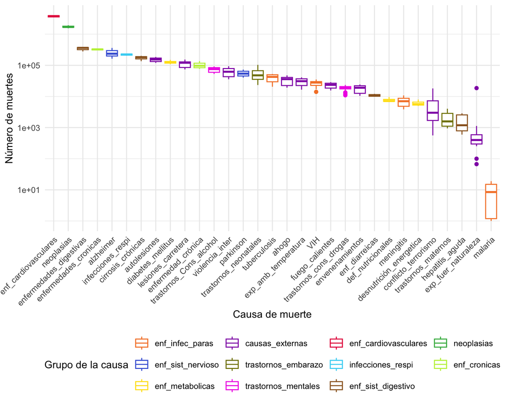

Figura 1: Boxplots del conteo anual de muertes totales, en escala logarítmica y ordenados en orden descendente según la mediana

En la Figura 2 se muestra el número de defunciones totales por cada causa de muerte, también ordenada de mayor a menor cantidad de fallecimientos.

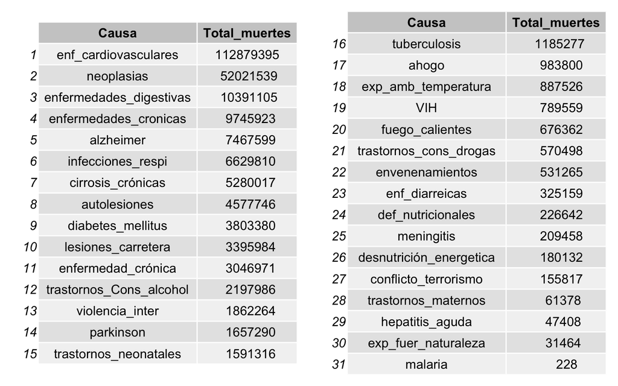

Figura 2: Conteo de muertes totales ordenado en orden descendente

Aquí podemos ver el conteo exacto de cada causa durante todo el intervalo temporal y se puede apreciar con más claridad que hay algunas causas que apenas causan impacto. Observemos que en este tiempo la malaria solo registra $228$ defunciones, mientras que enfermedades cardiovasculares registra más de cien millones. Por ello, con el objetivo de reducir dimensionalidad y manejar adecuadamente estas diferencias, vamos a agrupar las causas siguiendo el criterio de la OMS en [este enlace](https://icd.who.int/browse/2024-01/mms/en). Los grupos que nos quedan son los siguientes:

- Enfermedades infecciosas o parasitarias (*enf_infec_paras*). En este grupo incluimos *meningitis*, *malaria*, *VIH* y *tuberculosis*; color naranja en la Figura 1.
- Enfermedades del sistema nervioso (*enf_sist_nervioso*). En este grupo incluimos *alzheimer* y *parkinson*; color azul en la Figura 1.
- Enfermedades endocrinas, nutricionales o metabólicas (*enf_metabolicas*). En este grupo incluimos *def_nutricionales*, *diabetes_mellitus* y *desnutrición_energetica*; color amarillo en la Figura 1.
- Causas externas de morbilidad o mortalidad, lesiones y envenenamientos (*causas_externas*). En este grupo incluimos *ahogo*, *violencia_inter*, *autolesiones*, *exp_fuer_naturaleza*, *conflicto_terrorismo*, *lesiones_carretera*, *exp_amb_temperatura*, *envenenamientos* y *fuego_calientes*; color púrpura en la Figura 1.
- Causas relacionadas con el embarazo, parto o puerperio (en la madre) y afecciones en el periodo perinatal (en el hijo) (*trastornos_embarazo*). En este grupo incluimos *trastornos_maternos* y *trastornos_neonatales*; color oliva en la Figura 1.
- Trastornos mentales, del comportamiento o del desarrollo neurológico (*trastornos_mentales*). En este grupo incluimos *trastornos_cons_drogas* y *trastornos_Cons_alcohol*; color magenta en la Figura 1.
- Enfermedades del sistema circulatorio (*enf_cardiovasculares*). En este grupo incluimos *enf_cardiovasculares*; color rojo en la Figura 1.
- Enfermedades del sistema respiratorio (*infecciones_respi*). En este grupo incluimos *infecciones_respi*; color cian en la Figura 1.
- Enfermedades del sistema digestivo (*enf_sist_digestivo*). En este grupo incluimos *enf_diarreicas*, *cirrosis_crónicas*, *enfermedades_digestivas* y *hepatitis_aguda*; color marrón en la Figura 1.
- Neoplasias (*neoplasias*). En este grupo incluimos *neoplasias*; color verde en la Figura 1.
- Enfermedades crónicas (*enf_cronicas*). En este grupo incluimos *enfermedad_crónica* y *enfermedades_cronicas*; color lima en la Figura 1.

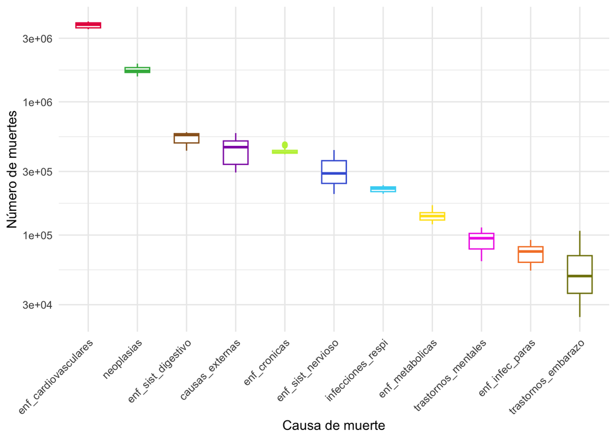

Figura 3: Boxplots del conteo anual de muertes totales agrupadas y ordenadas en orden descendente según la mediana

Una vez agrupadas las causas de muerte, en la Figura 3 se muestran los boxplots resultantes de los conteos de muertes totales. De nuevo, apreciamos grandes diferencias entre la causa con más conteos (enfermedades cardiovasculares) y la causa con menos conteos (trastornos del embarazo). Sin embargo, esta última ya tiene un conteo mayor que en el anterior gráfico, con decenas de miles de defunciones. Y con este agrupamiento, la Figura 4 muestra el número total de fallecimientos por cada causa de la nueva agrupación.

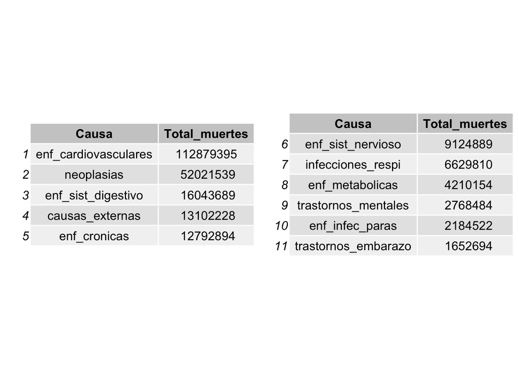

Figura 4: Conteo de muertes totales ordenado en orden descendente.

De nuevo, podemos ver el conteo exacto de cada causa ordenado de mayor a menor. Se aprecia que, tras la agrupación, la causa con menos muertes en todo este periodo ya supera el millón de casos, con lo que hemos reducido las diferencias.

Por último, recordemos que disponemos de las siguientes covariables: *poblacion*, *pib*, *idh*, *esperanza_vida_m*, *esperanza_vida_h*, *esperanza_vida*, *emisiones_CO_2*, *emisiones_CO_2_PIB* y *emisiones_CO_2_per_capita*. Estas variables aportan información descriptiva sobre las causas de muerte, aunque presentan redundancias: el IDH se calcula a partir del PIB y de la esperanza de vida, por lo que podríamos prescindir de ellas; y, como a mayor población suele corresponder un mayor nivel de emisiones de CO$_2$, tampoco es necesario incluir *emisiones_CO_2* como covariable. En efecto, podemos observar las elevadas correlaciones entre estas variables en la matriz mostrada en la Figura 5.

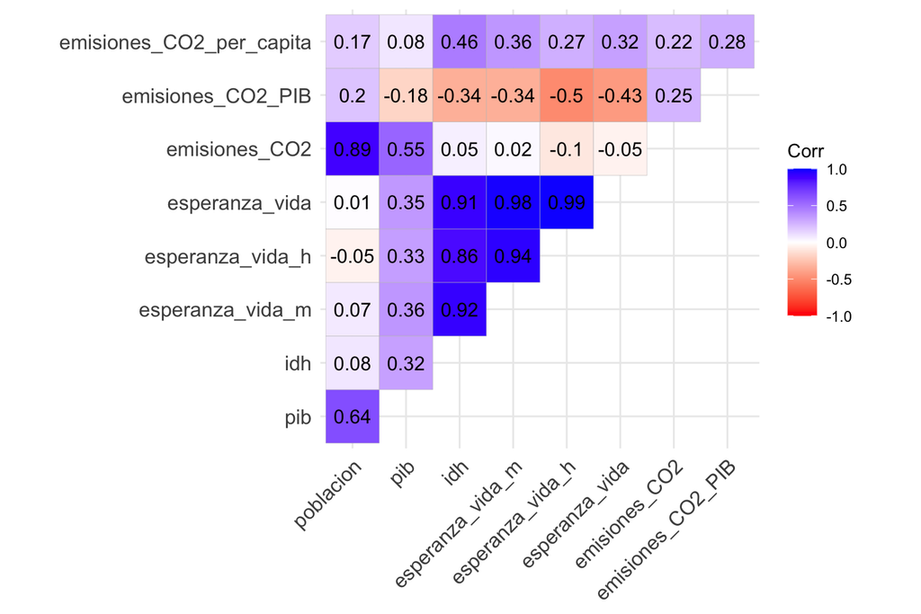

Figura 5: Matriz de correlaciones de las covariables. Tonos azules indican correlación positiva y tonos rojos correlación negativa.

En la Figura 5 podemos ver efectivamente que *idh* está altamente correlacionado con las variables relacionadas con la esperanza de vida. También vemos una alta correlación entre *poblacion* y *emisiones_CO2*. Sin embargo, la correlación entre *idh* y *pib* no es tan alta, pero esto es debido a que el IDH se calcula a partir del logaritmo del PIB, por lo que no tienen alta correlación lineal.

De esta forma, consideraremos únicamente las covariables *poblacion*, *idh*, *emisiones_CO2_PIB* y *emisiones_CO2_per_capita* en la base de datos.

Después de aplicar las transformaciones explicadas en esta sección, obtenemos la base de datos final con la que vamos a trabajar. En la Tabla 2 mostramos los datos que nos ofrecen las cinco primeras mediciones de esta base de datos.

| Nombre de la variable | 1 | 2 | 3 | 4 | 5 |
| --- | --- | --- | --- | --- | --- |
| *pais* | Albania | Albania | Albania | Albania | Albania |
| *codigo_Pais* | ALB | ALB | ALB | ALB | ALB |
| *año* | 1990 | 1991 | 1992 | 1993 | 1994 |
| *poblacion* | 3295066 | 3302082 | 3303739 | 3300711 | 3293999 |
| *enf_infec_paras* | 154 | 158 | 149 | 139 | 126 |
| *enf_sist_nervioso* | 453 | 459 | 459 | 460 | 463 |
| *enf_metabolicas* | 172 | 189 | 192 | 194 | 192 |
| *causas_externas* | 893 | 979 | 987 | 963 | 949 |
| *trastornos_embarazo* | 897 | 887 | 870 | 858 | 847 |
| *trastornos_mentales* | 15 | 18 | 18 | 21 | 27 |
| *enf_cardiovasculares* | 6701 | 6903 | 6699 | 6480 | 6191 |
| *infecciones_respi* | 2140 | 2196 | 2104 | 1977 | 1795 |
| *enf_sist_digestivo* | 1054 | 1071 | 1038 | 997 | 945 |
| *neoplasias* | 2616 | 2698 | 2642 | 2586 | 2493 |
| *enf_cronicas* | 1247 | 1255 | 1200 | 1144 | 1064 |
| *total_muertes* | 16342 | 16813 | 16358 | 15819 | 15092 |
| *idh* | 64.7 | 62.9 | 61.4 | 61.7 | 62.4 |
| *emisiones_CO2_PIB* | 0.42 | 0.39 | 0.23 | 0.20 | 0.19 |
| *emisiones_CO2_per_capita* | 2.03 | 1.35 | 0.75 | 0.71 | 0.76 |

Tabla 2: Base de datos final luego de aplicar el preprocesamiento explicado en esta sección.

## 3 - Tratamiento de datos composicionales

Las variables que nos dan información sobre las causas de fallecimiento tienen naturaleza composicional, ya que todas las entradas son positivas (son conteos de defunciones); y la única información relevante en cada fila es la relación entre las componentes, ya que esta nos da el porcentaje de muertes por cada causa.

Antes de poder aplicar técnicas de análisis de datos composicionales hay que pre-procesar los datos siguiendo los pasos explicados en [3], que son imputación de ceros y transformación logarítmica.

### 3.1 - Imputación de ceros

Hay varias estrategias para imputar ceros. Primero, nos interesa saber cuántos conteos de ceros hay en cada variable, es decir, en cuántas mediciones (país-año) no ha habido muertes por esa causa, estos conteos son mostrados en la Tabla 3.

| **Nombre de la variable** | **Nº ceros** |
| --- | --- |
| *trastornos_embarazo* | 26 |
| *trastornos_mentales* | 30 |

Tabla 3: Número de conteos iguales a cero para cada causa de fallecimiento

La siguiente salida nos da el porcentaje de ceros:

```
[1] 0.3689065
```

En total hay $56$ ceros, que de un total de $15180$ entradas, supone un $0.3689\%$. Solo se muestra trastornos del embarazo y mentales, porque el resto de las causas analizadas no presenta conteos iguales a cero. Como el porcentaje es menor a $10\%$, seguimos el método más sencillo que consiste en sustituir los ceros por una cantidad fija de $0,65$ tal como lo sugieren en [2].

### 3.2 - Transformación CLR

Recordemos que un vector de datos composicionales $\mathbf{x} = (x_1, \ldots, x_n)$ tiene componentes positivas y suma un total constante. Por lo tanto, estos datos no viven en todo $\mathbb{R}^n$, sino en un subespacio restringido conocido como el simplex:
$$\mathcal{S}^n = \left\{(x_1, \ldots, x_n)\in\mathbb{R}^n \middle| \sum_{i=1}^nx_i = \kappa;\; x_i > 0,\; \forall i = 1, \ldots, n\right\}.$$
Esta restricción implica que las componentes no son independientes entre sí —un aumento en una parte debe compensarse con una disminución en otra— y esto viola supuestos básicos como la independencia o la homocedasticidad que subyacen a técnicas como la regresión lineal u otras basadas en la estadística clásica.

Para solventar este problema, podemos aplicar un isomorfismo entre el símplex y un espacio euclídeo tradicional. Hay tres isomorfismos bien caracterizados que transforman el símplex al espacio real:

1. Transformación log-ratio aditiva (ALR, por sus siglas en inglés) es un isomorfismo donde alr$:\mathcal{S}^n \to \mathbb{R}^{n-1}$ viene dado por
   $$\text{alr}(\mathbf{x}) = \left(\ln\left(\frac{x_1}{x_n}\right), \ldots, \ln\left(\frac{x_{n-1}}{x_n}\right)\right).$$
2. Transformación log-ratio centrada (CLR, por sus siglas en inglés) es una isometría donde clr$:\mathcal{S}^n \to U$, con $U = \{(y_1, \ldots, y_n) \in \mathbb{R}^n | \sum_{i=1}^n y_i = 0\} \subset \mathbb{R}^n$, viene dado por
   $$\text{clr}(\mathbf{x}) = \left(\ln\left(\frac{x_1}{g(\mathbf{x})}\right), \ldots, \ln\left(\frac{x_{n-1}}{g(\mathbf{x})}\right)\right),$$
   donde $g(\mathbf{x})$ es la media geométrica de $\mathbf{x}$, es decir,
   $$g(\mathbf{x}) = \left(\prod_{i=1}^nx_i\right)^\frac{1}{n}.$$
3. Transformación log-ratio isométrica (ILR, por sus siglas en inglés) es una isometría donde ilr$:\mathcal{S}^n \to \mathbb{R}^{n-1}$ viene dado por
   $$\text{ilr}(\mathbf{x}) = \left(\langle\mathbf{x}, \mathbf{e}_1\rangle, \ldots, \langle\mathbf{x}, \mathbf{e}_{n-1}\rangle\right),$$
   donde $\{\mathbf{e}_1, \ldots, \mathbf{e}_{n-1}\}$ es una base ortonormal del símplex.

Cada una de ellas tiene sus ventajas y desventajas. Nosotros utilizaremos la transformación CLR, donde cada coordenada transformada representa el logaritmo de la razón de cada componente respecto a la media geométrica de todas las partes. Esto significa que no se interpretan valores absolutos, sino desviaciones relativas: un valor CLR positivo indica que la parte correspondiente es mayor que la media geométrica de la composición, mientras que un valor negativo indica que es menor. Una vez aplicada esta transformación en las variables con naturaleza composicional (las causas de muerte), mostramos el resultado de las cuatro primeras mediciones en la Tabla 4.

| **Nombre de la variable** | **1** | **2** | **3** | **4** |
| --- | --- | --- | --- | --- |
| *pais* | Albania | Albania | Albania | *Albania* |
| *codigo_Pais* | ALB | ALB | ALB | ALB |
| *año* | 1990 | 1991 | 1992 | 1993 |
| *poblacion* | 3295066 | 3302082 | 3303739 | 3300711 |
| *enf_infec_paras* | -1.421125 | -1.441382 | -1.479668 | -1.535840 |
| *enf_sist_nervioso* | -0.3421852 | -0.3749270 | -0.3545639 | -0.3390876 |
| *enf_metabolicas* | -1.310583 | -1.262230 | -1.226119 | -1.202456 |
| *causas_externas* | 0.3365093 | 0.3825544 | 0.4110559 | 0.3997394 |
| *trastornos_embarazo* | 0.3409786 | 0.2838677 | 0.2848791 | 0.2842900 |
| *trastornos_mentales* | -3.750027 | -3.613605 | -3.593242 | -3.425792 |
| *enf_cardiovasculares* | 2.351935 | 2.335734 | 2.326099 | 2.306162 |
| *infecciones_respi* | 1.210484 | 1.190416 | 1.167981 | 1.119022 |
| *enf_sist_digestivo* | 0.5022704 | 0.4723708 | 0.4614369 | 0.4344367 |
| *neoplasias* | 1.411324 | 1.396289 | 1.395677 | 1.387554 |
| *enf_cronicas* | 0.6704186 | 0.6309136 | 0.6064627 | 0.5719721 |
| *total_muertes* | 16342 | 16813 | 16358 | 15819 |
| *idh* | 64.7 | 62.9 | 61.4 | 61.7 |
| *emisiones_CO2_PIB* | 0.42 | 0.39 | 0.23 | 0.20 |
| *emisiones_CO2_per_capita* | 2.03 | 1.35 | 0.75 | 0.71 |

Tabla 4: Base de datos obtenida a partir de la base mostrada en la Tabla 2 con transformación CLR

## 4 - Matriz de correlaciones

Analicemos la matriz de correlaciones de Spearman mostrada en la Figura Figura 6, de las causas de muerte y las covariables. Utilizamos la correlación de Spearman, en lugar de la de Pearson, ya que nuestras variables de interés —las causas de muerte— son de naturaleza discreta y pueden no cumplir los supuestos de normalidad y linealidad.

Examinar esta matriz es fundamental porque nos permite identificar relaciones potenciales de asociación entre diferentes causas de mortalidad y factores socioeconómicos o ambientales, como las emisiones de CO$_2$ o el IDH. Detectar correlaciones altas o patrones inusuales puede orientar el planteamiento de modelos explicativos más robustos, ayudar a evitar la multicolinealidad y aportar hipótesis plausibles sobre interacciones o factores comunes que afecten simultáneamente a varias causas de muerte.

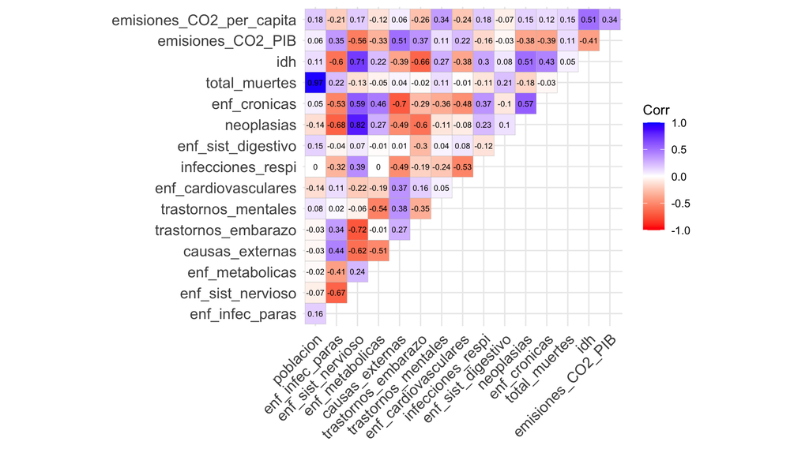

Figura 6: Matriz de correlaciones de Spearman entre los conteos de muertes y las covariables de la base.

Fijémonos primero en las correlaciones entre causas de muerte y covariables. Las variables *población* y *emisiones_CO2_per_capita* apenas tienen correlación con las causas de muerte. La variable *emisiones_CO2_PIB* tiene correlaciones más altas: las más significativas son con *enf_sist_nervioso* y *causas_externas*. Por otro lado, la variable *idh* presenta altas correlaciones con algunas causas, tanto positivamente como negativamente. Esto es debido a que un IDH bajo corresponde a países poco desarrollados y podemos ver en las correlaciones negativas enfermedades que suelen ser comunes en estos países: enfermedades infecciosas y parasitarias, las cuales recordemos que engloban a meningitis, malaria, VIH y tuberculosis; y trastornos del embarazo, los cuales engloban trastornos maternos y neonatales. Luego, en las correlaciones positivas, podemos ver enfermedades del sistema nervioso, que engloba alzheimer y parkinson; neoplasias y enfermedades crónicas.

Por último, vemos que hay algunas enfermedades bastante correlacionadas y otras que no. La correlación positiva que más destaca es entre enfermedades del sistema nervioso y neoplasias, con un valor de $0.82$; mientras que la correlación negativa más destacada es entre enfermedades del sistema nervioso y trastornos del embarazo, con un valos de $-0.72$. La correlaciones más pequeña en valor absoluto, con un valor de $0$, corresponde a enfermedades metabólicas con infecciones respiratorias.

Cabe destacar el caso de la variable *total_muertes* que no tiene ninguna correlación considerable exceptuando con *población*, la cual es obvia.

## 5 - Tendencias temporales

En este apartado vamos a estudiar las tendencias temporales de cada causa de muerte. Para ello, vamos a trabajar con una base de datos resultante de sumar los conteos de todos los países, es decir, vamos a ver la evolución temporal de cada causa a nivel europeo. La estructura de la base de datos es mostrada en la Tabla 5.

| **año** | **1990** | **1991** | **1992** | **1993** | **1994** |
| --- | --- | --- | --- | --- | --- |
| *enf_infec_paras* | 60594 | 63604 | 68723 | 78164 | 87625 |
| *enf_sist_nervioso* | 203318 | 210386 | 216637 | 223731 | 229549 |
| *enf_metabolicas* | 120422 | 122416 | 123916 | 126732 | 128387 |
| *causas_externas* | 443676 | 463734 | 504519 | 551287 | 582808 |
| *trastornos_embarazo* | 107599 | 101728 | 94695 | 89298 | 85891 |
| *trastornos_mentales* | 63639 | 69365 | 78402 | 90635 | 99876 |
| *enf_cardiovasculares* | 3511347 | 3567511 | 3656760 | 3872094 | 3996749 |
| *infecciones_respi* | 218396 | 215852 | 217936 | 228723 | 233884 |
| *enf_sist_digestivo* | 429695 | 436562 | 448848 | 471906 | 490331 |
| *neoplasias* | 1550681 | 1572939 | 1604179 | 1660453 | 1687884 |
| *enf_cronicas* | 404001 | 406141 | 410952 | 425140 | 430979 |

Tabla 5: Estructura de la tabla de datos de defunciones por año y covariables mostradas mediante la instrucción str de R.

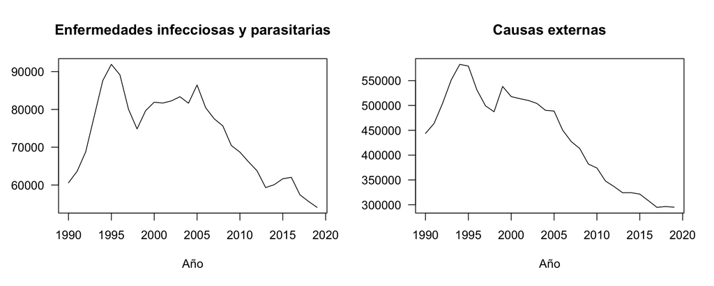

Figura 7: Conteos totales por año de muertes por enfermedades infecciosas y parasitarias y por causas externas de morbilidad o mortalidad, lesiones y envenenamientos.

En estas figuras vemos un comportamiento alcista durante los primeros años hasta alcanzar sus máximos alrededor de 1995, para luego seguir con un comportamiento bajista y acabar en 2019 con una cantidad inferior a la cantidad de muertes iniciales, aunque este comportamiento en la figura de la derecha es bastante más inferior que en la figura de la izquierda

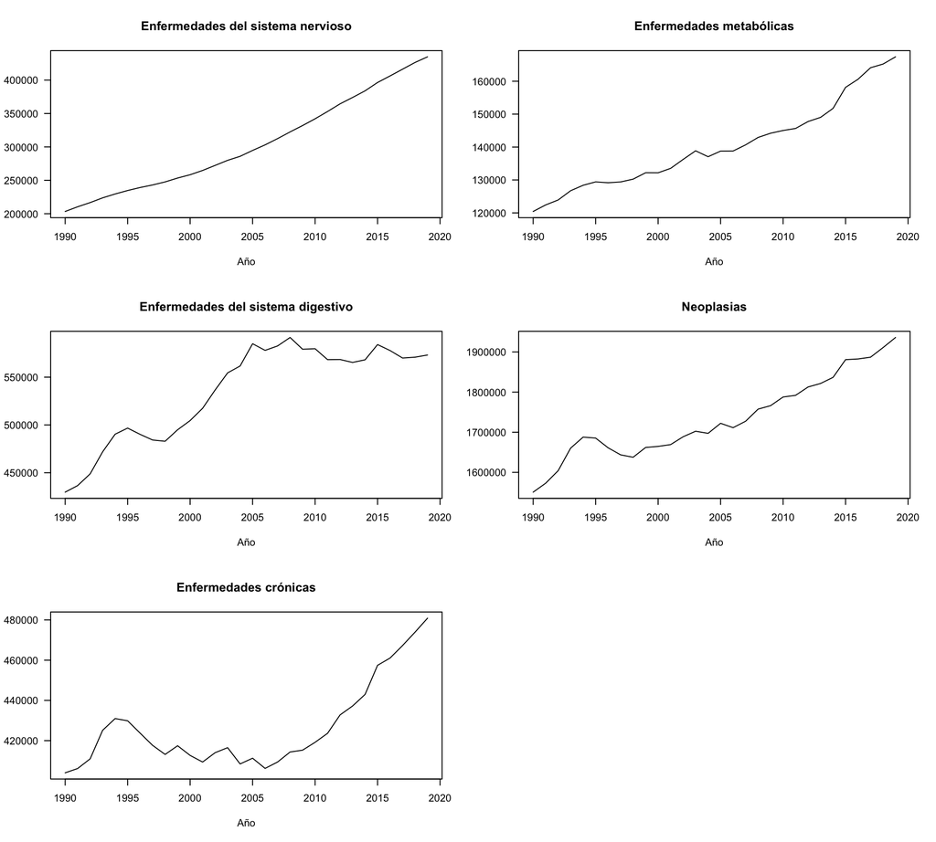

Figura 8: Conteos totales por año de muertes por enfermedades del sistema nervios; enfermedades endocrinas, nutricionales o metabólicas; enfermedades del sistema digestivo; neoplasias; y enfermedades crónicas.

En estas figura, podemos ver una clara tendencia alcista del número de muertes. Sin embargo, las defunciones por enfermedades del sistema digestivo se han estabilizado entre $550000$ y $600000$ a partir de 2005, y en las defunciones por enfermedades crónicas tenemos la tendencia alcista a partir de 2006.

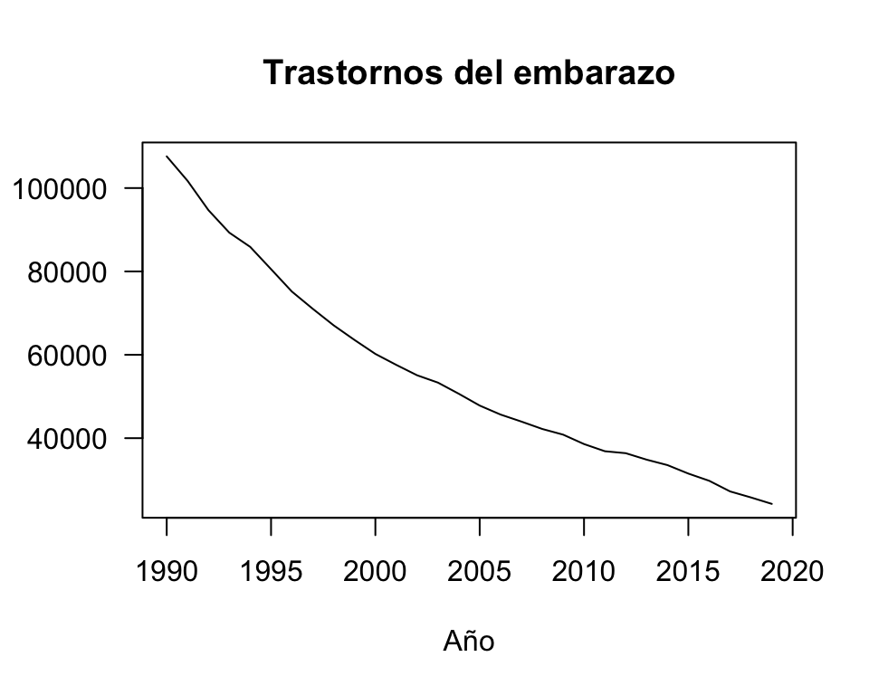

Figura 9: Conteos totales por año de muertes por causas relacionadas con el embarazo, parto o puerperio y afecciones en el periodo perinatal.

En esta figura podemos apreciar una clara tendencia bajista, siendo la cantidad de muertes de 2019 más de un $75\%$ inferior a la cantidad de 1990.

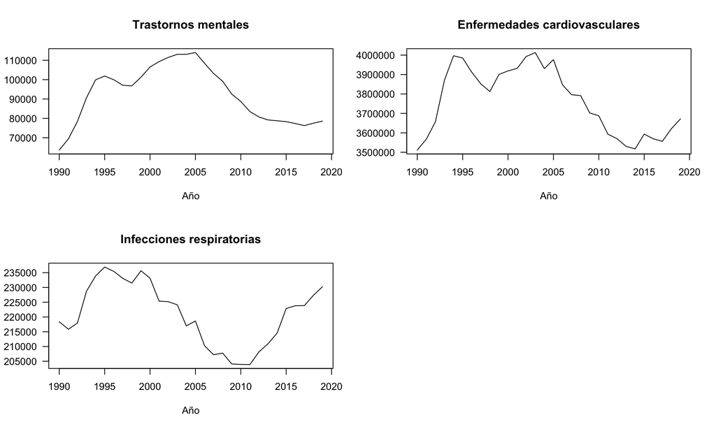

Figura 10: Conteos totales por año de muertes por trastornos mentales, del comportamiento o del desarrollo neurológico; enfermedades del sistema circulatorio; y enfermedades del sistema respiratorio.

En estas figuras se observa un comportamiento sinusoidal, con tendencias alcistas y bajistas en diferentes ventanas temporales. Las primeras dos causas tienen su mínimo en 1990, mientras que la tercera lo tiene en 2011. Por otro lado, el máximo de la primera lo alcanza en 2005, la segunda en 2003 y la tercera en 1995.

Por último, veamos la evolución de todas las causas de muerte agrupadas de acuerdo al número medio de muertes: En la Figura 11 están las muertes cuyos conteos se consideran bajos (entre $20.000$ y $170.000$), medios (entre $200.000$ y $600.000$), y altos (entre $1.550.000$ y $4.020.000$).

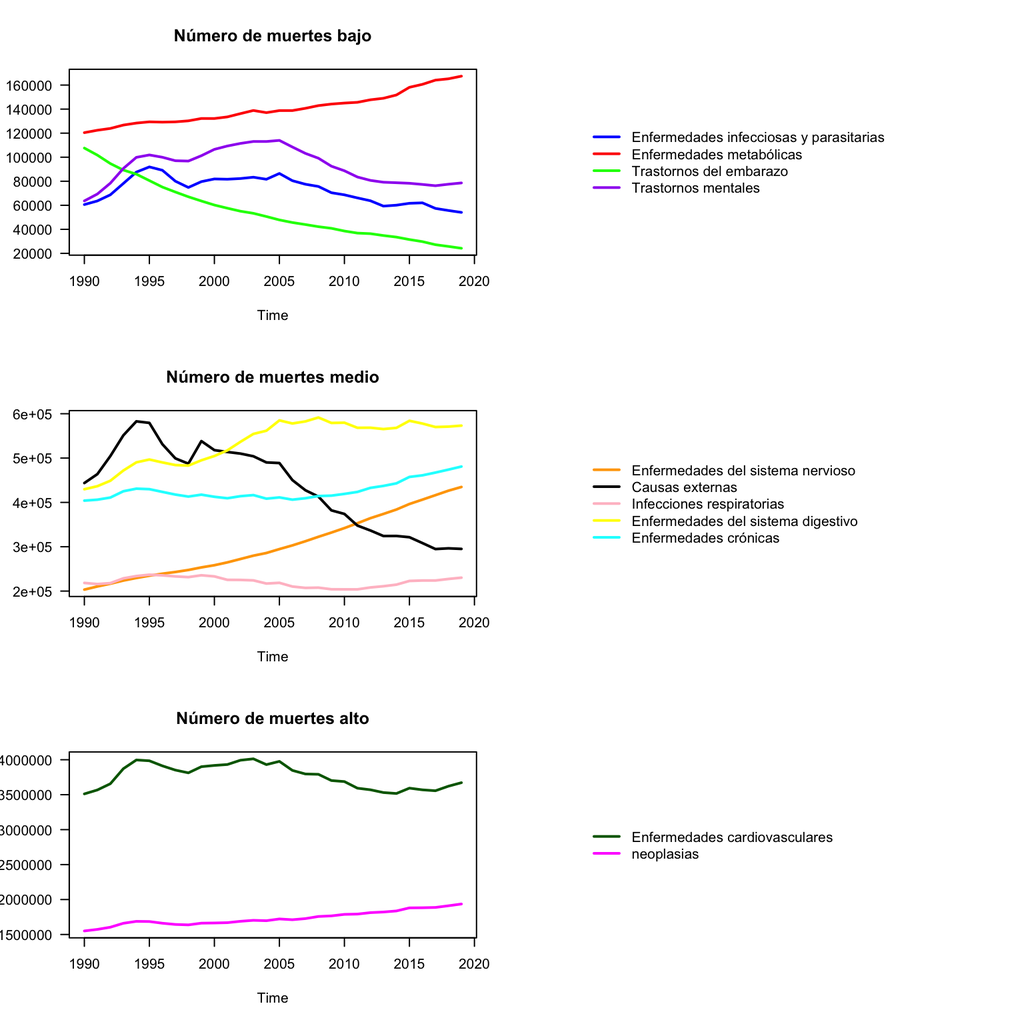

Figura 11: Evolución temporal de las causas con número de muertes bajo (entre 20.000 y 170.000), medio (entre 200.000 y 600.000) y alto (entre 1.550.000 y 4.020.000).

## 6 - Análisis en componentes principales

En este apartado se presenta un Análisis en Componentes Principales (ACP), una técnica estadística que permite reducir la dimensión de los datos y visualizar sus patrones de variabilidad conservando la mayor cantidad de información posible. Exploraremos en detalle las medianas temporales para cada país. Además, en el Anexo A.1 se incluyen los gráficos de los ACP realizados exclusivamente con los datos de 1990 y 2019, correspondientes al inicio y final del periodo analizado. El objetivo principal es observar si se producen cambios significativos en los patrones de agrupación entre países a lo largo del tiempo.

Este análisis se basa en una base de datos construida a partir de la mediana temporal de cada causa de muerte y del IDH por país. Durante la elaboración de la base de datos indentificamos dos valores nulos (0), que imputamos con el valor $0,65$ para poder aplicar la transformación CLR. Tras esta transformación, los datos son centrados para llevar a cabo el ACP.

```
# A tibble: 1 × 1
  total_ceros
        <int>
1           2
```

Antes de realizar el método de componentes principales, mostraremos la matriz de varianzas-covarianzas.

```
Matriz de varianzas-covarianzas
```

```
                     enf_infec_paras enf_sist_nervioso enf_metabolicas
enf_infec_paras           0.45962841       -0.21104586     -0.20321300
enf_sist_nervioso        -0.21104586        0.21548869      0.07701702
enf_metabolicas          -0.20321300        0.07701702      0.40747533
causas_externas           0.12569614       -0.08915561     -0.14727394
trastornos_embarazo       0.13720098       -0.21737959      0.07382990
trastornos_mentales       0.06216285       -0.05834067     -0.33252523
enf_cardiovasculares      0.02881971       -0.03946454     -0.03907456
infecciones_respi        -0.14200506        0.10840577      0.01159016
enf_sist_digestivo        0.02177634       -0.01832753     -0.02712961
neoplasias               -0.15496611        0.13694347      0.06253884
enf_cronicas             -0.12405441        0.09585884      0.11676509
                     causas_externas trastornos_embarazo trastornos_mentales
enf_infec_paras           0.12569614          0.13720098          0.06216285
enf_sist_nervioso        -0.08915561         -0.21737959         -0.05834067
enf_metabolicas          -0.14727394          0.07382990         -0.33252523
causas_externas           0.15264778         -0.01506810          0.18170191
trastornos_embarazo      -0.01506810          0.66043248         -0.34550694
trastornos_mentales       0.18170191         -0.34550694          0.72369244
enf_cardiovasculares      0.05342544          0.03607488          0.02053999
infecciones_respi        -0.12071350         -0.06170254         -0.09445249
enf_sist_digestivo        0.01378099         -0.05175434          0.02356167
neoplasias               -0.05306541         -0.17239868         -0.03441642
enf_cronicas             -0.10197569         -0.04372804         -0.14641710
                     enf_cardiovasculares infecciones_respi enf_sist_digestivo
enf_infec_paras               0.028819712       -0.14200506        0.021776337
enf_sist_nervioso            -0.039464540        0.10840577       -0.018327535
enf_metabolicas              -0.039074558        0.01159016       -0.027129615
causas_externas               0.053425440       -0.12071350        0.013780987
trastornos_embarazo           0.036074878       -0.06170254       -0.051754341
trastornos_mentales           0.020539988       -0.09445249        0.023561674
enf_cardiovasculares          0.094083792       -0.09114066        0.006839361
infecciones_respi            -0.091140658        0.26997763       -0.018394783
enf_sist_digestivo            0.006839361       -0.01839478        0.078810735
neoplasias                   -0.009612539        0.04655474       -0.009503442
enf_cronicas                 -0.060490877        0.09188073       -0.019659379
                       neoplasias enf_cronicas
enf_infec_paras      -0.154966108  -0.12405441
enf_sist_nervioso     0.136943474   0.09585884
enf_metabolicas       0.062538838   0.11676509
causas_externas      -0.053065411  -0.10197569
trastornos_embarazo  -0.172398676  -0.04372804
trastornos_mentales  -0.034416418  -0.14641710
enf_cardiovasculares -0.009612539  -0.06049088
infecciones_respi     0.046554743   0.09188073
enf_sist_digestivo   -0.009503442  -0.01965938
neoplasias            0.123888001   0.06403754
enf_cronicas          0.064037538   0.12778331
```

En la matriz de varianzas-covarianzas observamos que las varianzas oscilan entre $0,0788$ (para *enf_sist_digestivo*) y $0,7237$ (para *trastornos_mentales*). Esta diferencia justifica la necesidad de escalar las variables antes de aplicar el ACP, ya que, en caso contrario, las componentes principales estarían dominadas por las variables con mayor varianza. Veamos de una forma más clara las varianzas ordenadas de menor a mayor.

```
  enf_sist_digestivo enf_cardiovasculares           neoplasias
          0.07881073           0.09408379           0.12388800
        enf_cronicas      causas_externas    enf_sist_nervioso
          0.12778331           0.15264778           0.21548869
   infecciones_respi      enf_metabolicas      enf_infec_paras
          0.26997763           0.40747533           0.45962841
 trastornos_embarazo  trastornos_mentales
          0.66043248           0.72369244
```

En la Figura 12 se muestra la matriz de correlaciones de Pearson basada en las medianas temporales por país.

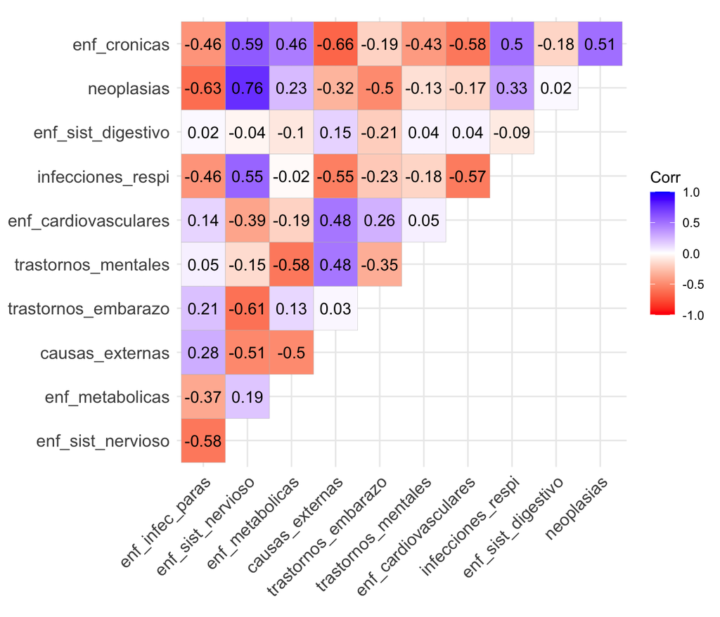

Figura 12: Matriz de correlaciones de Pearson calculada a partir de las medianas temporales por país.

La correlación positiva más fuerte se observa entre *enf_sist_nervioso* y *neoplasias* ($r = 0,76$), mientras que la más negativa se da entre *causas_externas* y *enf_cronicas* ($r = −0,66$).

Pasemos al estudio de las componentes principales. Calculemos los valores y vectores propios de la matriz de varianzas-covarianzas.

```
Vectores propios
```

```
                             PC1          PC2         PC3         PC4
enf_infec_paras       0.34920146  0.138918812 -0.25167506  0.07063549
enf_sist_nervioso    -0.38309369 -0.289683158  0.11797771 -0.08163132
enf_metabolicas      -0.27937119  0.316384032  0.35617650  0.15941142
causas_externas       0.38706501 -0.225188351  0.09213182 -0.13435495
trastornos_embarazo   0.13351622  0.596987506  0.02730497 -0.12986777
trastornos_mentales   0.21069579 -0.493784742 -0.18992480 -0.19321510
enf_cardiovasculares  0.24358978 -0.047939181  0.61959501 -0.05448668
infecciones_respi    -0.30160498 -0.003787135 -0.51042307 -0.06414445
enf_sist_digestivo    0.09845823 -0.164468820 -0.03295815  0.93801720
neoplasias           -0.34084995 -0.324065596  0.31066194 -0.04703037
enf_cronicas         -0.40624676  0.106668259 -0.09245102  0.03891734
                             PC5         PC6         PC7          PC8
enf_infec_paras      -0.21754366  0.69697913 -0.34371004 -0.010048526
enf_sist_nervioso     0.10358226  0.22575029  0.01025448  0.270403531
enf_metabolicas      -0.45049287 -0.29799340 -0.32052580  0.276681513
causas_externas      -0.12538008  0.03280905  0.58586986  0.486064804
trastornos_embarazo   0.25905793 -0.16306824  0.30451342 -0.012139343
trastornos_mentales  -0.21586838 -0.45477738 -0.16061479 -0.348664052
enf_cardiovasculares  0.49329372  0.08290542 -0.18137435 -0.329591129
infecciones_respi     0.54073951 -0.09476218 -0.15696079  0.214769933
enf_sist_digestivo    0.15214402 -0.08986165  0.13520098 -0.004395798
neoplasias            0.03807109  0.27597886  0.05009535  0.053312678
enf_cronicas         -0.22189230  0.19968490  0.48880491 -0.578478452
                             PC9         PC10       PC11
enf_infec_paras      -0.01484152 -0.013055185 -0.3724202
enf_sist_nervioso     0.39707352  0.625405357 -0.2550011
enf_metabolicas      -0.27354730  0.027542313 -0.3506553
causas_externas      -0.36023863  0.028242765 -0.2146224
trastornos_embarazo   0.45616224 -0.119226689 -0.4464203
trastornos_mentales   0.13792265 -0.013859121 -0.4673118
enf_cardiovasculares -0.31955084  0.171046147 -0.1684950
infecciones_respi    -0.42757266 -0.089137831 -0.2854261
enf_sist_digestivo    0.09475754 -0.003336136 -0.1542135
neoplasias            0.15646287 -0.731607611 -0.1933501
enf_cronicas         -0.30333968  0.142377059 -0.1963662
```

Podemos ver que entre la primera y segunda componente le dan un peso considerable a todas las variables, aunque *enf_sist_digestivo* y *enf_cardiovasculares* son las que menos peso tienen.

```
Valores propios
```

```
         eigenvalue variance.percent cumulative.variance.percent
Dim.1  4.504083e+00     4.094621e+01                    40.94621
Dim.2  2.196328e+00     1.996662e+01                    60.91283
Dim.3  1.329300e+00     1.208455e+01                    72.99738
Dim.4  9.889199e-01     8.990181e+00                    81.98756
Dim.5  6.300997e-01     5.728179e+00                    87.71574
Dim.6  5.300500e-01     4.818637e+00                    92.53437
Dim.7  2.696369e-01     2.451245e+00                    94.98562
Dim.8  2.501030e-01     2.273664e+00                    97.25928
Dim.9  1.731724e-01     1.574295e+00                    98.83358
Dim.10 1.283067e-01     1.166425e+00                   100.00000
Dim.11 1.639045e-29     1.490041e-28                   100.00000
```

A partir de esta tabla de valores podemos ver que con dos componentes principales nos permiten explicar aproximadamente el $61\%$ de la variación total. Una manera más detallada de ver el peso de estas componentes es mediante la Figura 13 donde se muestra un diagrama de barras donde a cada dimensión le asociamos el porcentaje de variación que explica:

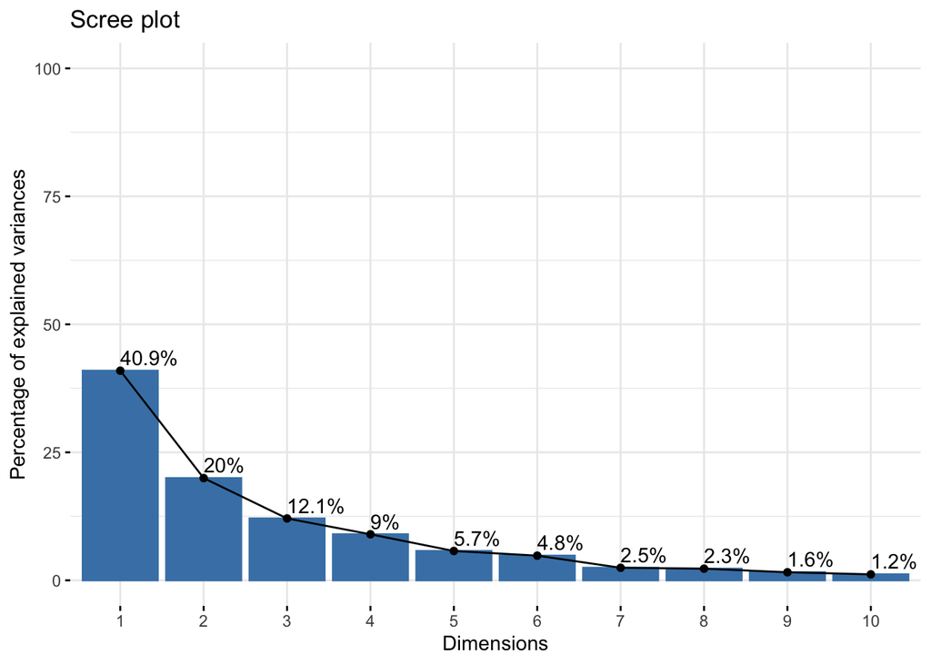

Figura 13: Porcentaje de varianza explicada por cada componente principal a partir de las medianas temporales por país.

A partir de la cuarta componente, el incremento en la varianza explicada es marginal, por lo que es razonable trabajar con dos o tres componentes. El círculo de correlaciones (Figura 14) permite visualizar las relaciones entre variables y su representación en el plano principal.

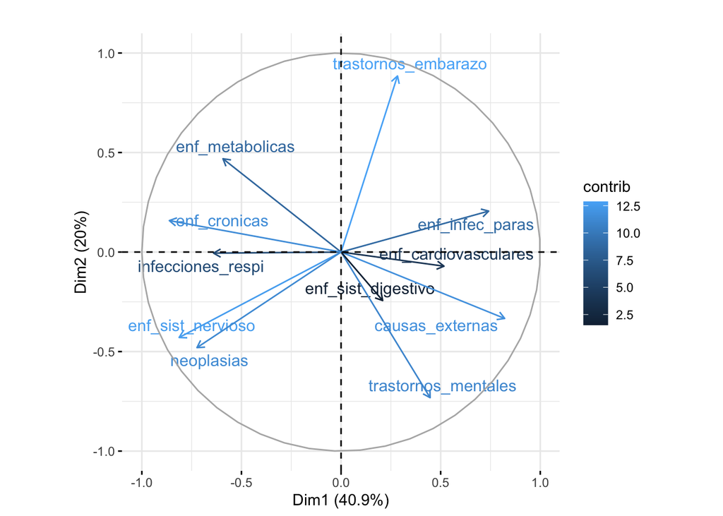

Figura 14: Círculo de correlaciones del ACP calculado a partir de las medianas temporales por país.

La mayoría de las variables están bien representadas en el plano principal, con excepción de *enf_cardiovasculares* y *enf_sist_digestivo*, que muestran una menor contribución. Las Figuras 15 y 16 muestran, respectivamente, las contribuciones individuales de las variables y su calidad de representación en el plano.

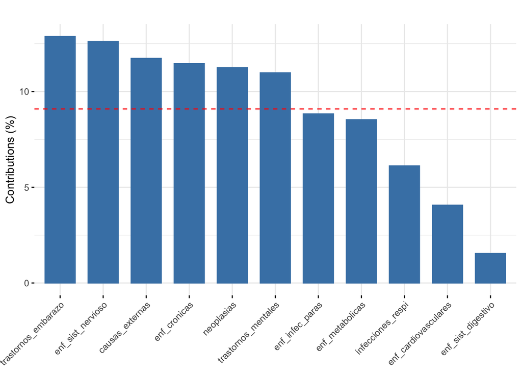

Figura 15: Contribuciones de cada variable al plano principal del ACP.

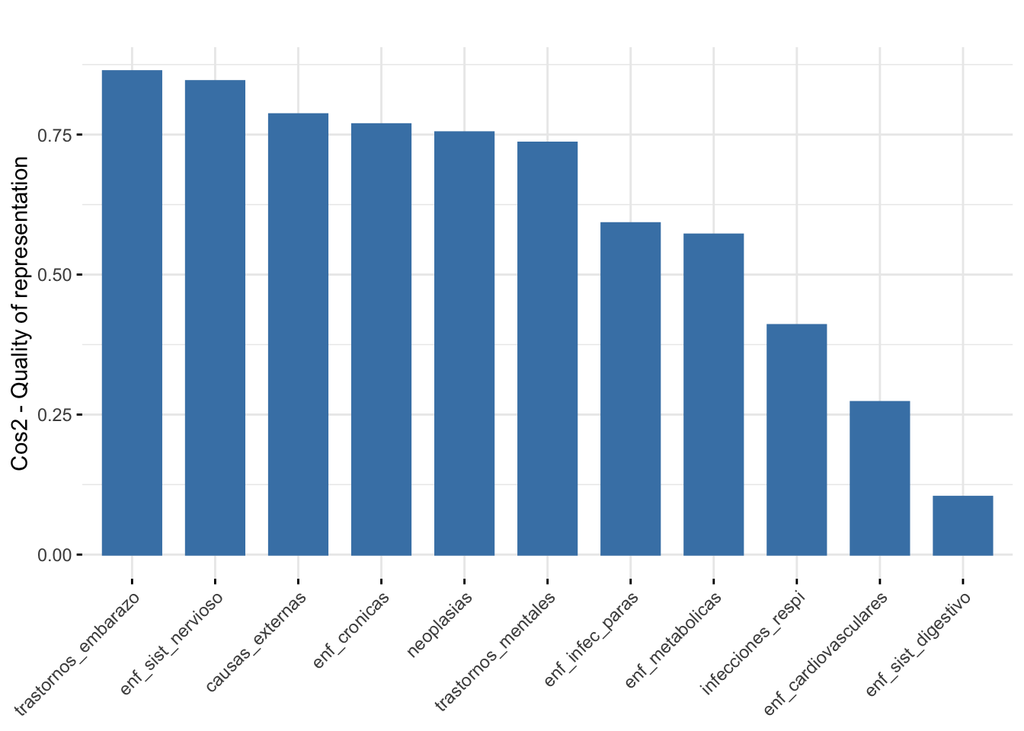

Figura 16: Calidad de representación ($\cos^2$) en el plano principal del ACP.

Finalmente, en la Figura 17 se presenta un biplot con la posición de cada país en el plano principal, coloreados según su IDH, dividido por cuartiles.

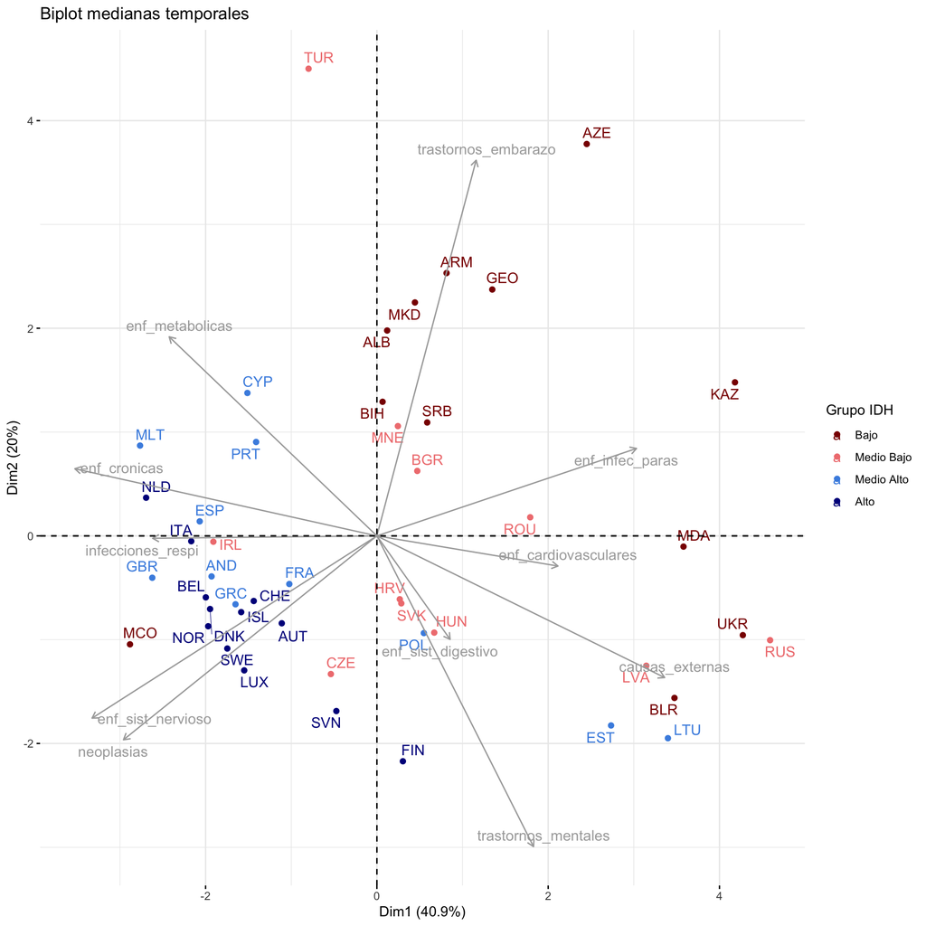

Figura 17: Representación de los países en el plano principal del ACP, coloreados según su IDH.

El gráfico muestra una clara estructura de agrupamiento según el nivel de desarrollo. Los países con mayor IDH se ubican principalmente en el tercer cuadrante, asociado a causas de muerte propias de contextos más desarrollados (como enfermedades del sistema nervioso y neoplasias). Por el contrario, los países con menor IDH se concentran en el primer cuadrante, caracterizado por enfermedades infecciosas y trastornos relacionados con el embarazo.

## 7 - Ajuste de modelo NBMM

Para finalizar, en este apartado abordamos el ajuste del NBMM propuesto en la sección 4 del capítulo 2 del trabajo para analizar el conteo de muertes en Europa. Antes de entrar en detalles, conviene justificar por qué utilizamos un modelo Binomial Negativo en lugar de uno Poisson, que suele ser el más usual para modelizar datos de conteo.

### Motivación para usar el modelo Binomial Negativo

Los modelos de regresión Poisson asumen que la media y la varianza de la variable respuesta son iguales (esto es, $E[Y] = \text{Var}(Y)$), lo que se conoce como *equidispersión*. Sin embargo, en el caso de conteo de muertes podemos observar *sobredispersión*, es decir, que la varianza exceda notablemente a la media. En esos casos, el modelo Poisson tiende a infravalorar la probabilidad de observar valores atípicamente altos, dando lugar a errores sistemáticos en la estimación de los parámetros y de las incertidumbres asociadas.

Para ilustrar intuitivamente este fenómeno, podríamos tomar los datos de un país concreto (por ejemplo, España) sobre muertes causadas por enfermedades del sistema nervioso entre 1990 y 2019. Si agrupáramos esos valores y tratáramos de calcular una media y varianza global, obtenemos

```
# A tibble: 1 × 2
    mean       var
   <dbl>     <dbl>
1 26382. 44076945.
```

donde claramente $\hat{\sigma}^2 \gg \hat{\mu}$. Aunque esta comparación numérica es meramente orientativa, puesto que cada año está asociado a diferentes variables aleatorias, sirve para ver que probablemente tendremos sobredispersión. Esto haría que el modelo Poisson:

- Subestime sistemáticamente la probabilidad de observar años con conteos muy altos.
- Proporcione intervalos de confianza demasiado estrechos para los parámetros.

Por eso, elegimos la regresión Binomial Negativa para nuestro conjunto de datos. Recordemos que en este modelo la varianza cumple:

$$\text{Var}(Y) = E[Y] + \alpha\ \bigl(E[Y]\bigr)^2,$$

siendo $\alpha > 0$ el parámetro de sobredispersión. Más adelante, cuando ajustemos el modelo veremos rigurosamente que:

- Si $\alpha \approx 0$, los datos se comportan aproximadamente como equidispersos.
- Si $\alpha$ es significativamente mayor que cero, es señal de sobredispersión en el conteo de muertes.

De esta manera, el parámetro $\alpha$ nos permitirá cuantificar la sobredispersión real de los datos, sin necesidad de depender de una media y varianza muestral imposibles de calcular en cada país–año.

### Descripción del modelo propuesto

Basándonos en la motivación anterior, proponemos el NBMM descrito en la sección 4 del capítulo 2 del trabajo. Modelaremos la variable que representa las muertes causadas por las enfermedades del sistema nervioso. El resto de causas se realizan de manera análoga.

Sea $Y_{ij}$ la variable aleatoria que representa el conteo de muertes causadas por las enfermedades del sistema nervioso en el país $i$ y el año $j$. Por ejemplo, $y_{41,1} = 14557$ son las defunciones en España ($i=41$) en el año 1990 ($j=1$) por esta causa. Supondremos que $Y_{ij} \sim \text{NB}(\mu_{ij},\alpha)$ y queremos ver cómo afecta el IDH y el tiempo a esta variable, añadiendo un *offset*, por ser datos composicionales, y efectos aleatorios, para capturar la variabilidad entre países. Así, la ecuación de nuestro modelo queda
$$\ln(\mu_{ij}) = \ln(N_{ij}) + \beta_{0} + \beta_{1}x_{ij} + \beta_{2}t_j + \beta_{3}t_j^2 + \beta_{4}t_j^3 + u_i,$$
es decir,
$$\mu_{ij} = N_{ij}\exp\left(\beta_{0} + \beta_{1}x_{ij} + \beta_{2}t_j + \beta_{3}t_j^2 + \beta_{4}t_j^3 + u_i\right),$$
donde:

- $N_{ij}$ es el número total de fallecimientos en el país $i$ en el año $j$.
- $x_{ij}$ es el IDH del país $i$ en el año $j$.
- $t_j$ es el año reescalado, es decir, $t_j = \frac{j - 1}{29}$.
- $\beta_{0}$, $\beta_{1}$, $\beta_{2}$, $\beta_{3}$, $\beta_{4}$ son los coeficientes a estimar.
- $u_i$ es el efecto aleatorio por país. Son realizaciones de una variable aleatoria que sigue la distribución $N(0,\sigma^2)$.

### Estimación del modelo

Para estimar el modelo, primero vamos a reescalar nuestra variable año de forma que caiga en el intervalo $[0,1]$ para evitar posibles errores por *overflow*. Además, al querer un polinomio cúbico necesitamos las variables año al cuadrado y año al cubo.

Para realizar la estimación, utilizamos la función `glmm.nb` del paquete `NBZIMM` [3], que permite ajustar modelos de regresión binomial negativa para datos de conteo con sobredispersión. Tal como se comentó anteriormente, aplicamos este modelo específicamente a los casos de muertes por enfermedades del sistema nervioso, dado que este paquete no permite estimar modelos multivariantes de forma conjunta.

Una vez estimado el modelo, empleamos la función `summary()`para examinar los valores estimados de los parámetros y evaluar su significancia estadística. La Tabla 6 resume las estimaciones de los coeficientes ($\mathbf{\beta}$), junto con su error estándar, el valor $t$ y el $p$-valor asociado para contrastar la hipótesis nula de que cada parámetro es igual a cero.

```r
N = new_data$total_muertes # offset

m_enf_sist_nervioso1 = glmm.nb(enf_sist_nervioso ~ idh + año + año2 + año3 + offset(log(N)),
                              random = ~ 1 | pais, data = new_data)
```

```
Computational iterations: 4
Computational time: 0.002 minutes
```

Tabla 6: Estimación de los parámetros del modelo binomial negativo.

```
Linear mixed-effects model fit by maximum likelihood
  Data: new_data
  AIC BIC logLik
   NA  NA     NA

Random effects:
 Formula: ~1 | pais
        (Intercept)  Residual
StdDev:   0.4031211 0.9991278

Variance function:
 Structure: fixed weights
 Formula: ~invwt
Fixed effects:  enf_sist_nervioso ~ idh + año + año2 + año3 + offset(log(N))
                Value  Std.Error   DF   t-value p-value
(Intercept) -3.683567 0.07389994 1330 -49.84533  0.0000
idh          0.002111 0.00059922 1330   3.52268  0.0004
año          0.083668 0.07521046 1330   1.11245  0.2661
año2         1.081848 0.17606800 1330   6.14449  0.0000
año3        -0.581503 0.11543809 1330  -5.03736  0.0000
 Correlation:
     (Intr) idh    año    año2
idh  -0.581
año  -0.065 -0.055
año2  0.132 -0.087 -0.955
año3 -0.131  0.104  0.898 -0.985

Standardized Within-Group Residuals:
        Min          Q1         Med          Q3         Max
-3.17174511 -0.53921465  0.03949879  0.44186844  6.18317641

Number of Observations: 1380
Number of Groups: 46
```

Analizando los resultados, observamos que el intercepto ($\beta_0$) es significativamente distinto de cero ($p$-valor $< 0,001$), lo que sugiere una tasa de base relevante en el conteo de muertes. Asimismo, los coeficientes $\beta_1$, $\beta_3$ y $\beta_4$ presentan valores $t$ elevados y $p$-valores muy bajos, indicando que las covariables correspondientes tienen un efecto estadísticamente significativo sobre la variable respuesta.

En contraste, el coeficiente $\beta_2$, correspondiente a la variable *año*, no resulta significativo ($p$-valor $= 0,2661$), por lo que podría considerarse su exclusión o una reinterpretación de su efecto dentro del modelo.

Estos resultados permiten interpretar la magnitud y dirección de los efectos de cada covariable sobre el número de muertes, teniendo en cuenta la naturaleza logarítmica del enlace utilizado en la regresión binomial negativa. La validación del modelo debería completarse mediante un análisis de residuos y la comprobación de los supuestos del modelo, con el fin de garantizar la robustez de las conclusiones obtenidas.

La estimación $b_k$ corresponde al valor calculado por el método de scoring. Este estimador sigue, asintóticamente, una distribución normal con media el parámetro $\beta_k$ y varianza igual al inverso de la información observada, $\mathfrak{J}_k^{-1}$ (el error estándar al cuadrado). Por lo tanto:

$$\frac{b_k-\beta_k}{\sqrt{\mathfrak{J}_k^{-1}}} \underset{n \to \infty}{\sim} N(0, 1).$$

Cuando el tamaño muestral no es lo suficientemente grande, esta estadística sigue una distribución $t$ de Student. En nuestro caso, dado que $n = 1380$, se puede aproximar por una distribución normal estándar.

El $p$-valor asociado corresponde al siguiente contraste de hipótesis:

$$\begin{cases}
H_0: \; \beta_k = 0,\\
H_1: \; \beta_k \ne 0.\\
\end{cases}$$

El valor $z$ (denominado $t$ en la tabla) se calcula como:

$$z_k = \frac{b_k - 0}{\sqrt{\mathfrak{J}_k^{-1}}},$$

y el $p$-valor se obtiene como:

$$p_k = 2\cdot P(Z \ge |z_k|), \quad \text{con } Z \sim N(0,1).$$

Utilizamos un nivel de significación del 5%: si $p_k < 0,05$, se rechaza la hipótesis nula y se concluye que el coeficiente $\beta_k$ es significativamente distinto de cero.

Como se puede ver, todos los coeficientes excepto $\beta_2$ son estadísticamente significativos. En el caso de $\beta_2$, con un $p$-valor del $26,61\,\%$, no se puede rechazar la hipótesis nula. Por tanto, planteamos la posibilidad de eliminar esta covariable del modelo y comparar ambas versiones.

A continuación, presentamos los resultados de un segundo modelo, en el que se ha excluido la variable correspondiente a $\beta_2$:

```r
m_enf_sist_nervioso0 = glmm.nb(enf_sist_nervioso ~ idh + año2 + año3 + offset(log(N)),
                              random = ~ 1 | pais, data = new_data)
```

```
Computational iterations: 4
Computational time: 0.002 minutes
```

```
Linear mixed-effects model fit by maximum likelihood
  Data: new_data
  AIC BIC logLik
   NA  NA     NA

Random effects:
 Formula: ~1 | pais
        (Intercept)  Residual
StdDev:   0.4029578 0.9977562

Variance function:
 Structure: fixed weights
 Formula: ~invwt
Fixed effects:  enf_sist_nervioso ~ idh + año2 + año3 + offset(log(N))
                Value  Std.Error   DF   t-value p-value
(Intercept) -3.678163 0.07366921 1331 -49.92810   0e+00
idh          0.002147 0.00059746 1331   3.59387   3e-04
año2         1.268723 0.05209944 1331  24.35196   0e+00
año3        -0.696646 0.05076545 1331 -13.72284   0e+00
 Correlation:
     (Intr) idh    año2
idh  -0.586
año2  0.235 -0.472
año3 -0.166  0.349 -0.979

Standardized Within-Group Residuals:
        Min          Q1         Med          Q3         Max
-3.24693687 -0.53937977  0.04366694  0.46331326  6.06825967

Number of Observations: 1380
Number of Groups: 46
```

Para comparar estos dos modelos calculamos la diferencia de devianzas $\Delta D$ como estadístico de bondad de ajuste. Sea $M_0$ el modelo reducido (sin $\beta_2$), con hipótesis:

$$H_0:\; \mathbf{\beta} = (\beta_0, \beta_1, \beta_3, \beta_4)^\intercal,$$

y $M_1$ el modelo completo, que incluye la covariable correspondiente a $\beta_2$, con hipótesis:

$$H_1:\; \mathbf{\beta} = (\beta_0, \beta_1, \beta_2, \beta_3, \beta_4)^\intercal.$$

Ambos modelos se ajustan de forma similar al modelo saturado. La diferencia de devianzas es:

```
          [,1]
[1,] 0.3114133
```

y dado que $\Delta D \sim \chi^2(1)$, su $p$-valor asociado es:

```
          [,1]
[1,] 0.5768142
```

Este resultado indica que no existe evidencia suficiente para preferir el modelo completo sobre el modelo reducido. Por tanto, optamos por el modelo más simple ($M_0$) por razones de parsimonia.

```
                          (Intercept)
Albania                   0.021889725
Andorra                   0.373171296
Armenia                  -0.461563720
Austria                   0.309936808
Azerbaiyán               -0.829789178
Bélgica                   0.337254878
Bielorrusia              -0.370553165
Bosnia-Herzegovina       -0.255359792
Bulgaria                 -0.430751567
Chipre                   -0.047076273
Croacia                  -0.087410685
Dinamarca                 0.205224803
Eslovaquia               -0.145839163
Eslovenia                 0.245539530
España                    0.595931036
Estonia                  -0.150485865
Finlandia                 0.298511289
Francia                   0.559365868
Georgia (desambiguación) -0.209193576
Grecia                    0.205058582
Hungría                  -0.235226943
Irlanda (isla)            0.176084399
Islandia                  0.542512106
Italia                    0.479246256
Kazajistán               -0.861148214
Letonia                  -0.237235950
Lituania                 -0.194793745
Luxemburgo                0.277949642
Malta                     0.312472442
Moldavia                 -0.591297570
Mónaco                    0.491660903
Montenegro               -0.180534004
Noruega                   0.472861107
Países Bajos              0.397619886
Polonia                  -0.012118489
Portugal                  0.141545022
Reino Unido               0.325046773
Republica Checa          -0.008947796
República de Macedonia   -0.557673839
Rumania                  -0.360888964
Rusia                    -0.640922231
Serbia                   -0.506521378
Suecia                    0.535513385
Suiza                     0.594924146
Turquía                   0.035876690
Ucrania                  -0.559864465
```

Tabla 7: Efectos aleatorios $u_i$ estimados para cada país.

### Interpretación del modelo ajustado

En definitiva, el modelo binomial negativo ajustado para las muertes por enfermedades del sistema nervioso es:

$$\ln(\mu_{ij}) = \ln(N_{ij}) - 3.678163 + 0.002147x_{ij} + 1.268723t_j^2 - 0.696646t_j^3 + u_i,$$

es decir,

$$\begin{aligned}
\mu_{ij} &= N_{ij}\exp\left(-3.678163 + 0.002147x_{ij} + 1.268723t_j^2 - 0.696646t_j^3 + u_i\right) \\
&= N_{ij} \cdot e^{-3.678163} \cdot e^{0.002147x_{ij}} \cdot e^{1.268723t_j^2} \cdot e^{-0.696646t_j^3} \cdot e^{u_i} \\
&= N_{ij} \cdot 0.025269 \cdot 1.002150^{x_{ij}} \cdot 3.556309^{t_j^2} \cdot 0.498254^{t_j^3} \cdot e^{u_i},
\end{aligned}$$

donde $u_i \sim N(0, 0.4029578)$ representa el efecto aleatorio asociado al país.

De esta forma, el producto
$$0.025269 \cdot 1.002150^{x_{ij}} \cdot 3.556309^{t_j^2} \cdot 0.498254^{t_j^3}$$
representa la proporción estimada de defunciones por enfermedades del sistema nervioso para un país con determinado IDH en un año específico. El término $1.002150^{x_{ij}}$ muestra cómo influye el IDH: por ejemplo, si un país tiene un IDH máximo ($x_{ij} = 100$), el factor sería aproximadamente $1.2395$, lo cual representa un aumento del $23,95\,\%$ en el número de defunciones por esta causa.

Esta proporción se multiplica por el número total de muertes $N_{ij}$ para obtener el conteo esperado. Finalmente, el efecto aleatorio $e^{u_i}$ permite ajustar la estimación según las desviaciones particulares de cada país respecto a la tendencia global. Esto resulta especialmente útil para capturar variabilidad estructural no explicada por las covariables incluidas en el modelo. Por ejemplo, dos países con el mismo IDH en el mismo año podrían presentar niveles diferentes de mortalidad debido a factores no observados (como políticas sanitarias, infraestructuras o hábitos de vida).

Veamos ahora cómo varía este factor de ajuste ($e^{u_i}$) entre países en el siguiente mapa de Europa:

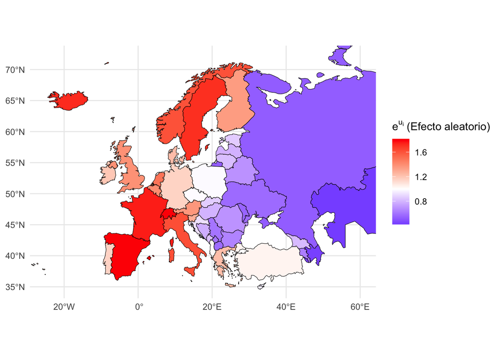

### Análisis de residuales

Para evaluar la calidad del ajuste del modelo, analizamos los residuales de Pearson, definidos como:

$$r_{P,ij} = \frac{y_{ij} - \hat{\mu}_{ij}}{\sqrt{\hat{\mu}_{ij} + a\hat{\mu}_{ij}^2}},$$

donde:

- $y_{ij}$ es el número observado de muertes en el país $i$ y año $j$,
- $\hat{\mu}_{ij}$ es el valor estimado de muertes,
- $a$ es el parámetro de sobredispersión estimado, es decir, $\alpha$.

Cuanto más cercano a cero es un residual, mejor es el ajuste para esa observación. A continuación, mostramos cómo se distribuyen los residuales en función de distintas covariables del modelo.

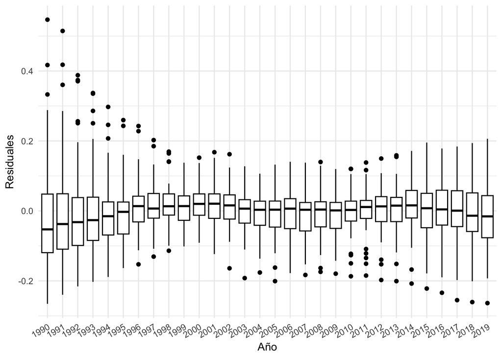

Figura 18: Distribución de los residuales de Pearson por año.

En la Figura 18 se observa que el ajuste es mejor alrededor del año 2000, donde las cajas son más estrechas y la mediana se aproxima a $0$. A medida que nos alejamos hacia los extremos del marco temporal, aumenta la variabilidad, lo que indica un ajuste menos preciso en esos periodos.

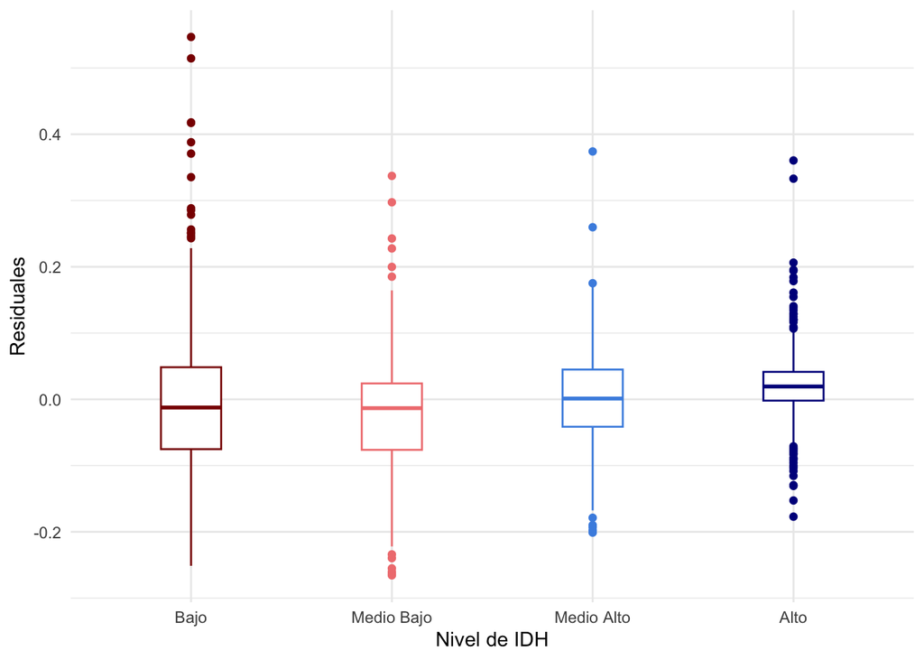

Figura 19: Distribución de los residuales de Pearson por IDH.

La Figura 19 muestra que, conforme aumenta el IDH, el modelo se ajusta mejor. Este comportamiento es coherente con la elevada correlación entre el IDH y la tasa de muertes por enfermedades del sistema nervioso.

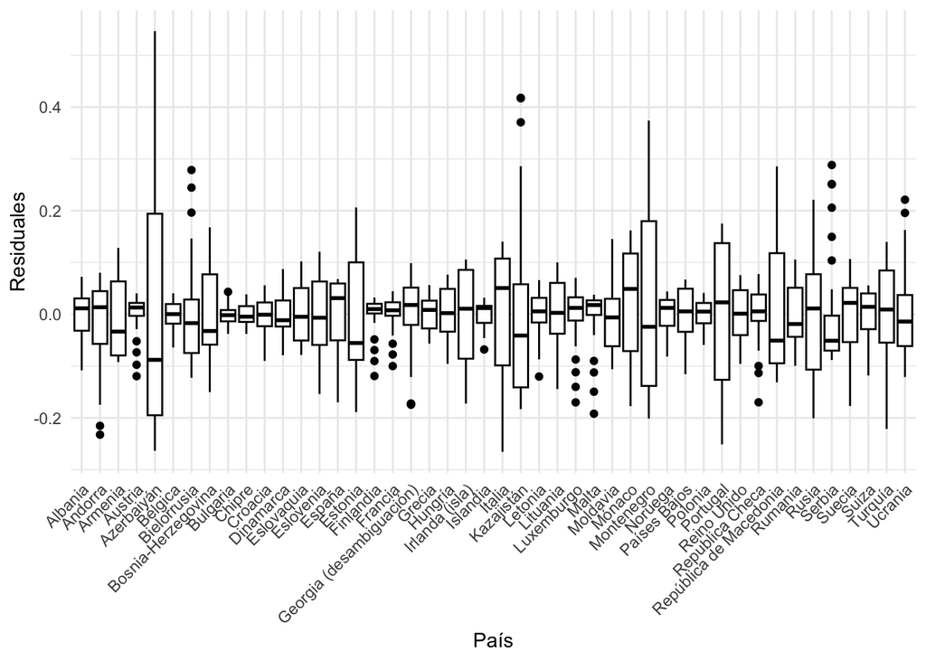

Figura 20: Distribución de los residuales de Pearson por país.

Por último, en la Figura 20 se evidencian diferencias entre países. En algunos como Azerbaiyán, Montenegro o Portugal, el modelo no se ajusta adecuadamente; mientras que en otros como Bulgaria, Finlandia o Francia, se observa un mejor ajuste. Como cada caja resume los datos de un mismo país a lo largo del tiempo, estas diferencias pueden deberse, en parte, a la suposición de un parámetro de sobredispersión constante en todos los países, lo cual podría no reflejar adecuadamente la heterogeneidad estructural de cada nación.

El modelo binomial negativo ajustado para las enfermedades del sistema nervioso ha demostrado ser una herramienta adecuada para modelar datos de conteo con sobredispersión. La incorporación de efectos aleatorios por país ha permitido capturar diferencias no observadas entre regiones, mejorando la interpretación y robustez del ajuste.

El IDH, inicialmente parecía relevante, y efectivamente resultó significativo en el modelo final, observado patrones importantes en la variabilidad de los residuos según su valor.

La estructura temporal capturada mediante términos cuadráticos y cúbicos del tiempo indica una evolución no lineal del fenómeno, compatible con transiciones epidemiológicas asociadas al desarrollo socioeconómico. El análisis de residuos confirma un buen ajuste global, aunque con ciertas limitaciones en los extremos temporales y en algunos países concretos.

En conjunto, este modelo proporciona una base sólida para interpretar tendencias de mortalidad por causas neurológicas y, en futuras extensiones, podría integrarse dentro de modelos más amplios o multivariantes para explorar patrones compartidos con otras causas de muerte.

## Apéndices

### A.1 - Análisis de componentes principales

#### ACP 1990

Veamos ahora un análisis en componentes principales donde tomaremos los datos de 1990. Durante la elaboración de la base de datos indentificamos un valor nulo (0), que imputamos con el valor $0,65$ para poder aplicar la transformación CLR. Tras esta transformación, los datos son centrados para llevar a cabo el ACP.

```
Rows: 1
Columns: 1
$ total_ceros <int> 1
```

Antes de realizar el método de componentes principales, observemos la matriz de varianzas-covarianzas y la matriz de correlación.

```
Matriz de varianzas-covarianzas
```

```
                     enf_infec_paras enf_sist_nervioso enf_metabolicas
enf_infec_paras          0.216550628       -0.10782562    -0.112244347
enf_sist_nervioso       -0.107825621        0.15410203     0.059121910
enf_metabolicas         -0.112244347        0.05912191     0.308843922
causas_externas          0.038279845       -0.04613673    -0.115015445
trastornos_embarazo      0.156260785       -0.23185649    -0.006669577
trastornos_mentales      0.025160557       -0.02279028    -0.283232327
enf_cardiovasculares    -0.041829231        0.02756519    -0.033413707
infecciones_respi       -0.042452420        0.02961042     0.042717866
enf_sist_digestivo      -0.001186881       -0.01731619     0.034135044
neoplasias              -0.094760670        0.11623045     0.039580268
enf_cronicas            -0.035952644        0.03929532     0.066176393
                     causas_externas trastornos_embarazo trastornos_mentales
enf_infec_paras          0.038279845         0.156260785          0.02516056
enf_sist_nervioso       -0.046136731        -0.231856488         -0.02279028
enf_metabolicas         -0.115015445        -0.006669577         -0.28323233
causas_externas          0.114413277         0.004220118          0.19099494
trastornos_embarazo      0.004220118         0.676929258         -0.25991108
trastornos_mentales      0.190994935        -0.259911082          0.71067096
enf_cardiovasculares     0.018303168        -0.055580658          0.06909179
infecciones_respi       -0.117170092         0.036597816         -0.26956246
enf_sist_digestivo      -0.014898277        -0.051563853         -0.04917073
neoplasias              -0.022906517        -0.208233521          0.00425763
enf_cronicas            -0.050084283        -0.060192797         -0.11550900
                     enf_cardiovasculares infecciones_respi enf_sist_digestivo
enf_infec_paras               -0.04182923       -0.04245242       -0.001186881
enf_sist_nervioso              0.02756519        0.02961042       -0.017316192
enf_metabolicas               -0.03341371        0.04271787        0.034135044
causas_externas                0.01830317       -0.11717009       -0.014898277
trastornos_embarazo           -0.05558066        0.03659782       -0.051563853
trastornos_mentales            0.06909179       -0.26956246       -0.049170726
enf_cardiovasculares           0.07792913       -0.05831310       -0.012397577
infecciones_respi             -0.05831310        0.38763379       -0.010735625
enf_sist_digestivo            -0.01239758       -0.01073563        0.122399450
neoplasias                     0.03148710       -0.02542380        0.002100116
enf_cronicas                  -0.02284209        0.02709761       -0.001365479
                       neoplasias enf_cronicas
enf_infec_paras      -0.094760670 -0.035952644
enf_sist_nervioso     0.116230449  0.039295318
enf_metabolicas       0.039580268  0.066176393
causas_externas      -0.022906517 -0.050084283
trastornos_embarazo  -0.208233521 -0.060192797
trastornos_mentales   0.004257630 -0.115508996
enf_cardiovasculares  0.031487099 -0.022842095
infecciones_respi    -0.025423795  0.027097606
enf_sist_digestivo    0.002100116 -0.001365479
neoplasias            0.116704717  0.040964224
enf_cronicas          0.040964224  0.112412753
```

En la matriz de varianzas-covarianzas observamos que las varianzas oscilan entre $0,0779$ (para *enf_cardiovasculares*) y $0,7107$ (para *trastornos_mentales*). Esta diferencia justifica la necesidad de escalar las variables antes de aplicar el ACP, ya que, en caso contrario, las componentes principales estarían dominadas por las variables con mayor varianza. Veamos de una forma más clara las varianzas ordenadas de menor a mayor.

```
enf_cardiovasculares         enf_cronicas      causas_externas
          0.07792913           0.11241275           0.11441328
          neoplasias   enf_sist_digestivo    enf_sist_nervioso
          0.11670472           0.12239945           0.15410203
     enf_infec_paras      enf_metabolicas    infecciones_respi
          0.21655063           0.30884392           0.38763379
 trastornos_embarazo  trastornos_mentales
          0.67692926           0.71067096
```

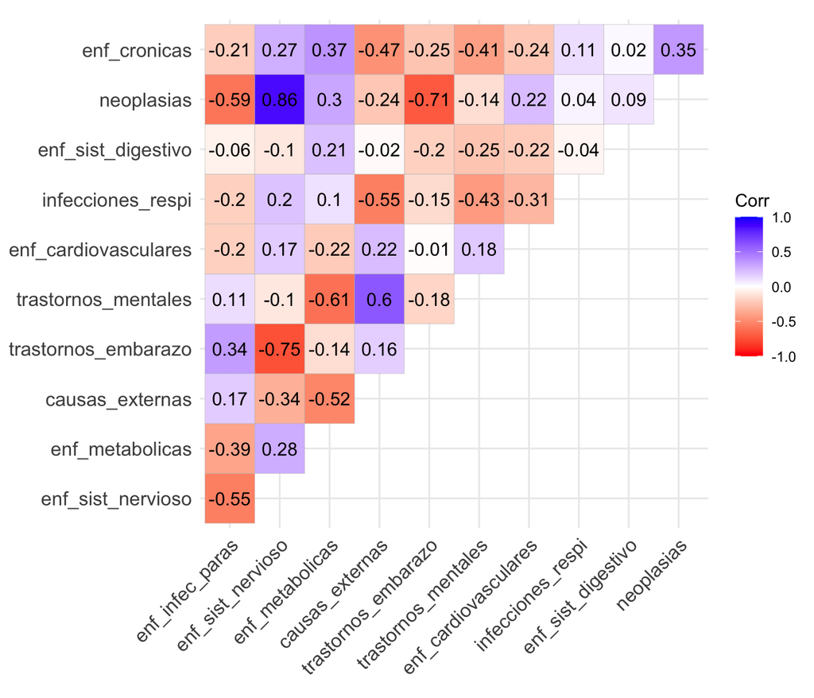

Figura 21: Matriz de correlaciones de Pearson calculada a partir de los datos de 1990.

La correlación positiva más fuerte se observa entre *enf_sist_nervioso* y *neoplasias* ($r = 0.86$), mientras que la más negativa se da entre *enf_sist_nervioso* y *trastornos_embarazo* ($r = -0.75$).

Pasemos al estudio de las componentes principales. Calculemos los valores y vectores propios de la matriz de varianzas-covarianzas.

```
Vectores propios
```

```
                             PC1         PC2         PC3         PC4
enf_infec_paras      -0.37739486 -0.15341765 -0.09017574 -0.36305145
enf_sist_nervioso     0.43906293  0.22926586  0.16301942 -0.10996887
enf_metabolicas       0.32867426 -0.26165260 -0.19991121  0.35981796
causas_externas      -0.34924308  0.33895946 -0.06539009 -0.06257968
trastornos_embarazo  -0.30003517 -0.37255160  0.20580583  0.35778912
trastornos_mentales  -0.22157975  0.46689991 -0.01933664 -0.20231476
enf_cardiovasculares  0.03935072  0.38706880  0.16803558  0.57457724
infecciones_respi     0.15874876 -0.33437312  0.37361945 -0.18075570
enf_sist_digestivo    0.05043297 -0.08272507 -0.84099285  0.08846882
neoplasias            0.41254267  0.30496430 -0.03810822 -0.08373264
enf_cronicas          0.31015494 -0.14926508 -0.04211940 -0.41966831
                             PC5          PC6         PC7         PC8
enf_infec_paras       0.07559483 -0.446806994  0.57880437  0.05988289
enf_sist_nervioso    -0.08509363 -0.007630757  0.36383159 -0.21469035
enf_metabolicas       0.28515246  0.430789163  0.26122536  0.18540465
causas_externas       0.13288143  0.244020077 -0.24878462 -0.59662032
trastornos_embarazo   0.22513594 -0.059222500 -0.06783193 -0.25850934
trastornos_mentales  -0.06126406  0.326785873 -0.06311320  0.52706790
enf_cardiovasculares -0.04391479 -0.562875620 -0.14028278  0.21210204
infecciones_respi    -0.64196432  0.031456750 -0.23574740 -0.03972099
enf_sist_digestivo   -0.37001376 -0.175443423 -0.16322546 -0.08646310
neoplasias            0.07678490 -0.129915515  0.15381046 -0.37566307
enf_cronicas          0.52610153 -0.281792375 -0.51801433  0.14212709
                             PC9        PC10       PC11
enf_infec_paras       0.25772819  0.10726273 -0.2687331
enf_sist_nervioso    -0.02248418 -0.69161468 -0.2266969
enf_metabolicas       0.39890331  0.14984208 -0.3209305
causas_externas       0.46988076 -0.03077649 -0.1953348
trastornos_embarazo  -0.48128472 -0.13345104 -0.4751307
trastornos_mentales  -0.24900095  0.01650408 -0.4868282
enf_cardiovasculares  0.28381026  0.01713027 -0.1612098
infecciones_respi     0.23964460  0.18375380 -0.3595442
enf_sist_digestivo   -0.10234308 -0.14971729 -0.2020371
neoplasias           -0.32024388  0.63191104 -0.1972812
enf_cronicas          0.09227327 -0.11356366 -0.1936196
```

Podemos ver que entre la primera y segunda componente le dan un peso considerable a todas las variables, menos a *enf_sist_digestivo*, la cual le da peso la tercera componente.

```
Valores propios
```

```
         eigenvalue variance.percent cumulative.variance.percent
Dim.1  3.589030e+00     3.262755e+01                    32.62755
Dim.2  2.850225e+00     2.591114e+01                    58.53868
Dim.3  1.143080e+00     1.039164e+01                    68.93032
Dim.4  9.613987e-01     8.739988e+00                    77.67031
Dim.5  8.761257e-01     7.964779e+00                    85.63509
Dim.6  5.659185e-01     5.144714e+00                    90.77980
Dim.7  4.613400e-01     4.194000e+00                    94.97380
Dim.8  3.117360e-01     2.833963e+00                    97.80777
Dim.9  1.692287e-01     1.538442e+00                    99.34621
Dim.10 7.191690e-02     6.537900e-01                   100.00000
Dim.11 1.606165e-29     1.460150e-28                   100.00000
```

A partir de esta tabla de valores podemos ver que con dos componentes principales nos permiten explicar aproximadamente el $58\%$ de la variación total. Una manera más detallada de ver el peso de estas componentes es mediante la Figura 22 donde se muestra un diagrama de barras donde a cada dimensión le asociamos el porcentaje de variación que explica:

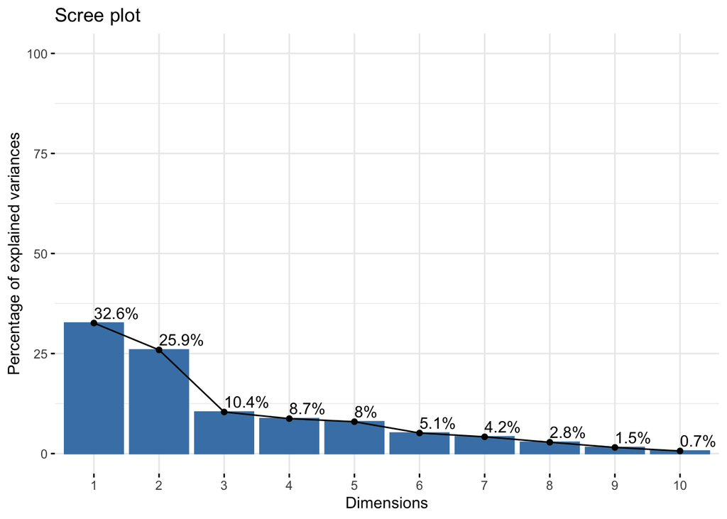

Figura 22: Porcentaje de varianza explicada por cada componente principal a partir de los datos de 1990.

A partir de la tercera componente, el incremento en la varianza explicada es marginal, por lo que es razonable trabajar con dos componentes. El círculo de correlaciones (Figura 23) permite visualizar las relaciones entre variables y su representación en el plano principal.

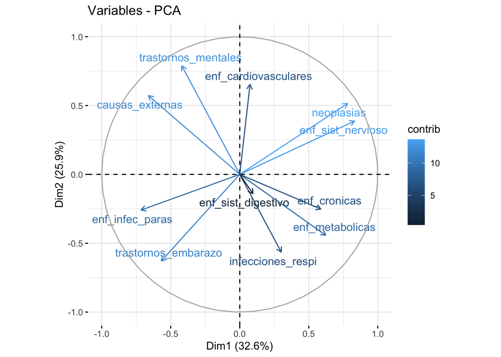

Figura 23: Círculo de correlaciones del ACP calculado a partir de los datos de 1990.

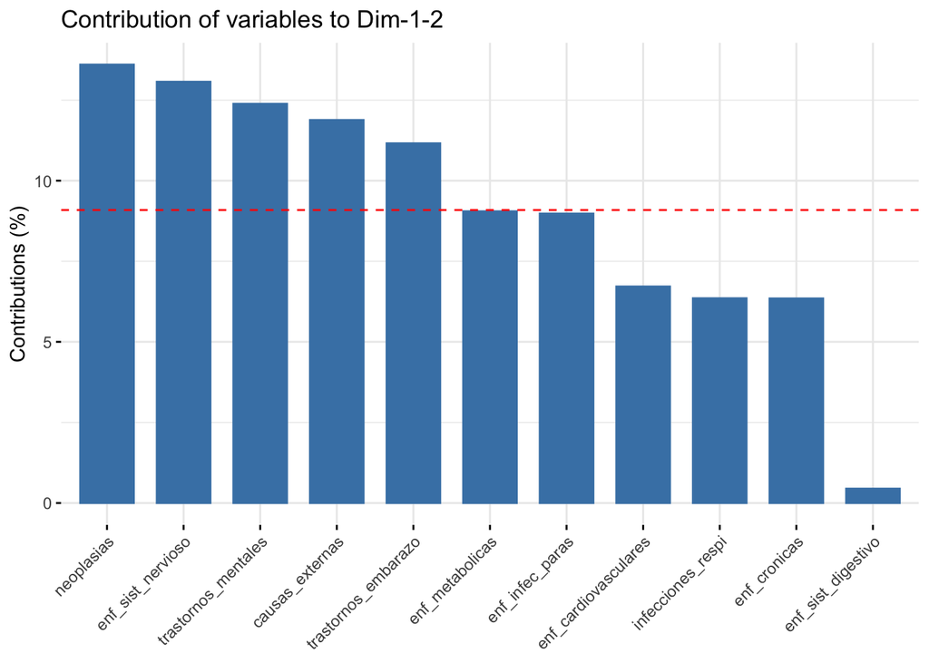

Figura 24: Contribuciones de cada variable al plano principal del ACP.

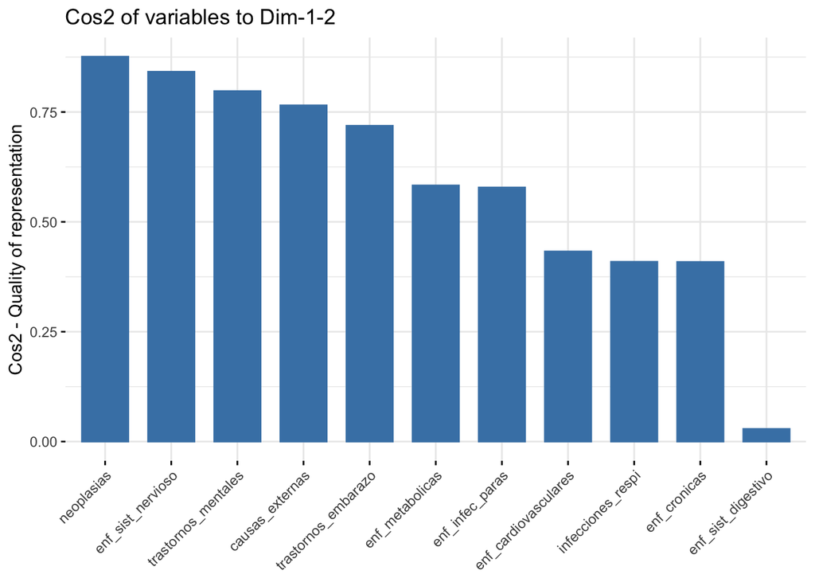

Figura 25: Calidad de representación ($\cos^2$) en el plano principal del ACP.

Finalmente, en la Figura 26 se presenta un biplot con la posición de cada país en el plano principal, coloreados según su IDH, dividido por cuartiles.

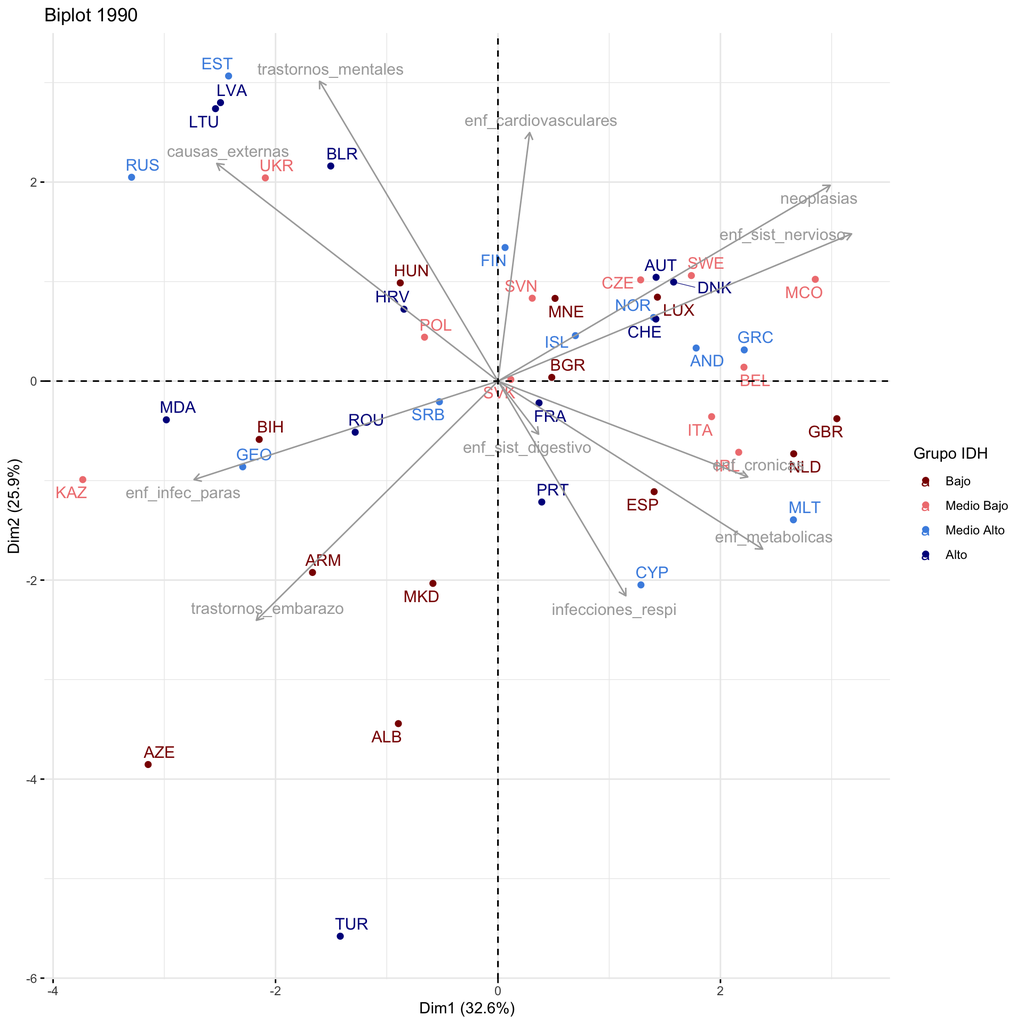

Figura 26: Representación de los países en el plano principal del ACP, coloreados según su IDH.

En este gráfico no podemos ver una agrupación clara.

#### ACP 2019

Veamos ahora un análisis en componentes principales donde tomaremos los datos de 2019. Durante la elaboración de la base de datos indentificamos tres valores nulos (0), que imputamos con el valor $0,65$ para poder aplicar la transformación CLR. Tras esta transformación, los datos son centrados para llevar a cabo el ACP.

```
Rows: 1
Columns: 1
$ total_ceros <int> 3
```

Antes de realizar el método de componentes principales, observemos la matriz de varianzas-covarianzas y la matriz de correlación.

```
Matriz de varianzas-covarianzas
```

```
                     enf_infec_paras enf_sist_nervioso enf_metabolicas
enf_infec_paras           0.52591010       -0.17684369    -0.211983432
enf_sist_nervioso        -0.17684369        0.18849283     0.022611515
enf_metabolicas          -0.21198343        0.02261151     0.413417558
causas_externas           0.12299825       -0.06740077    -0.103699010
trastornos_embarazo       0.06142779       -0.20148417     0.081427058
trastornos_mentales       0.04540491       -0.01941686    -0.311277341
enf_cardiovasculares      0.06639701       -0.03832670    -0.032740975
infecciones_respi        -0.14392176        0.10332992    -0.004462877
enf_sist_digestivo        0.04812600       -0.02500707    -0.041250347
neoplasias               -0.14301895        0.11524958     0.055259000
enf_cronicas             -0.19449623        0.09879542     0.132698851
                     causas_externas trastornos_embarazo trastornos_mentales
enf_infec_paras          0.122998252         0.061427789          0.04540491
enf_sist_nervioso       -0.067400771        -0.201484175         -0.01941686
enf_metabolicas         -0.103699010         0.081427058         -0.31127734
causas_externas          0.112315325         0.003598419          0.12257052
trastornos_embarazo      0.003598419         0.526289576         -0.25953491
trastornos_mentales      0.122570518        -0.259534905          0.73138636
enf_cardiovasculares     0.064021442         0.026787310         -0.01823353
infecciones_respi       -0.114169446        -0.059213842         -0.09230832
enf_sist_digestivo       0.020321483        -0.024835396          0.02190583
neoplasias              -0.053519605        -0.123919746         -0.06174700
enf_cronicas            -0.107036608        -0.030542089         -0.15874968
                     enf_cardiovasculares infecciones_respi enf_sist_digestivo
enf_infec_paras                0.06639701      -0.143921757         0.04812600
enf_sist_nervioso             -0.03832670       0.103329917        -0.02500707
enf_metabolicas               -0.03274097      -0.004462877        -0.04125035
causas_externas                0.06402144      -0.114169446         0.02032148
trastornos_embarazo            0.02678731      -0.059213842        -0.02483540
trastornos_mentales           -0.01823353      -0.092308317         0.02190583
enf_cardiovasculares           0.13490032      -0.124408440         0.01934691
infecciones_respi             -0.12440844       0.281080158        -0.02903145
enf_sist_digestivo             0.01934691      -0.029031447         0.06812191
neoplasias                    -0.01246041       0.063510358        -0.02143973
enf_cronicas                  -0.08528294       0.119595692        -0.03625814
                      neoplasias enf_cronicas
enf_infec_paras      -0.14301895  -0.19449623
enf_sist_nervioso     0.11524958   0.09879542
enf_metabolicas       0.05525900   0.13269885
causas_externas      -0.05351960  -0.10703661
trastornos_embarazo  -0.12391975  -0.03054209
trastornos_mentales  -0.06174700  -0.15874968
enf_cardiovasculares -0.01246041  -0.08528294
infecciones_respi     0.06351036   0.11959569
enf_sist_digestivo   -0.02143973  -0.03625814
neoplasias            0.10422646   0.07786005
enf_cronicas          0.07786005   0.18341568
```

En la matriz de varianzas-covarianzas observamos que las varianzas oscilan entre $0,0681$ (para *enf_sist_digestivo*) y $0,7314$ (para *trastornos_mentales*). Esta diferencia justifica la necesidad de escalar las variables antes de aplicar el ACP, ya que, en caso contrario, las componentes principales estarían dominadas por las variables con mayor varianza. Veamos de una forma más clara las varianzas ordenadas de menor a mayor.

```
  enf_sist_digestivo           neoplasias      causas_externas
          0.06812191           0.10422646           0.11231532
enf_cardiovasculares         enf_cronicas    enf_sist_nervioso
          0.13490032           0.18341568           0.18849283
   infecciones_respi      enf_metabolicas      enf_infec_paras
          0.28108016           0.41341756           0.52591010
 trastornos_embarazo  trastornos_mentales
          0.52628958           0.73138636
```

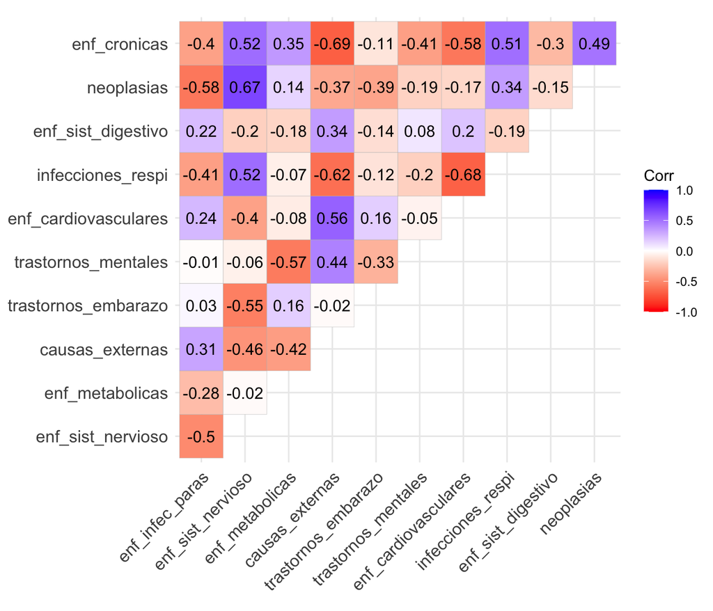

Figura 27: Matriz de correlaciones de Pearson calculada a partir de los datos de 2019.

La correlación positiva más fuerte se observa entre *enf_sist_nervioso* y *neoplasias* ($r = 0.67$), mientras que la más negativa se da entre *causas_externas* y *enf_cronicas* ($r = -0.69$).

Pasemos al estudio de las componentes principales. Calculemos los valores y vectores propios de la matriz de varianzas-covarianzas.

```
Vectores propios
```

```
                            PC1         PC2         PC3         PC4
enf_infec_paras       0.3476855  0.02638331  0.18214977 -0.19558768
enf_sist_nervioso    -0.3502260 -0.35963478 -0.19241148 -0.01573654
enf_metabolicas      -0.2313653  0.40756985 -0.31648977  0.02717368
causas_externas       0.3918773 -0.16037239 -0.14630368  0.19918159
trastornos_embarazo   0.1236024  0.59320003  0.13964238  0.13100188
trastornos_mentales   0.1738467 -0.48618795  0.22171509  0.36801936
enf_cardiovasculares  0.2565918  0.01251284 -0.62332291 -0.02772325
infecciones_respi    -0.3215388 -0.06330357  0.46467139 -0.16284811
enf_sist_digestivo    0.1852265 -0.13020524 -0.02717226 -0.85967896
neoplasias           -0.3611805 -0.23229135 -0.36356431 -0.02045026
enf_cronicas         -0.4121550  0.12162515  0.04693491 -0.04161916
                              PC5          PC6          PC7         PC8
enf_infec_paras      -0.456142693 -0.629528093 -0.009381898 -0.19091507
enf_sist_nervioso    -0.185860655  0.004556406 -0.116195984 -0.03016438
enf_metabolicas       0.434656647 -0.395194076  0.358919611  0.25832983
causas_externas      -0.007208228  0.009815357 -0.405917002  0.74823920
trastornos_embarazo  -0.069171189  0.468430383 -0.134724955 -0.12353776
trastornos_mentales   0.446692172  0.091189080  0.145995564 -0.28759007
enf_cardiovasculares -0.283930656  0.324038738  0.166113240 -0.21168631
infecciones_respi    -0.317116046  0.272335094  0.352723638  0.40013279
enf_sist_digestivo    0.369113391  0.184353623 -0.075196811  0.02279374
neoplasias           -0.193503992  0.026706514  0.025790669  0.02096893
enf_cronicas          0.096047166 -0.076088402 -0.703580673 -0.17944114
                              PC9        PC10       PC11
enf_infec_paras      -0.008926218 -0.07174244 -0.4010618
enf_sist_nervioso    -0.673428518  0.38807415 -0.2401060
enf_metabolicas      -0.013324754  0.11030996 -0.3555904
causas_externas       0.013174191 -0.01818242 -0.1853425
trastornos_embarazo  -0.358026687 -0.22226300 -0.4012065
trastornos_mentales   0.107821178 -0.04011691 -0.4729650
enf_cardiovasculares  0.365269814  0.33466409 -0.2031244
infecciones_respi     0.280542932  0.16200006 -0.2932045
enf_sist_digestivo   -0.078857803 -0.07411248 -0.1443441
neoplasias            0.079683204 -0.77814071 -0.1785437
enf_cronicas          0.426099038  0.17748996 -0.2368502
```

Podemos ver que entre la primera y segunda componente le dan un peso considerable a la mayoría de las variables, exceptuando quizás a *enf_infec_paras*, *enf_cardiovasculares*, *infecciones_respi* y *enf_sist_digestivo*, aunque la tercera y cuarta componentes ya les dan más peso.

```
Valores propios
```

```
         eigenvalue variance.percent cumulative.variance.percent
Dim.1  4.559371e+00     4.144882e+01                    41.44882
Dim.2  2.086194e+00     1.896540e+01                    60.41423
Dim.3  1.367380e+00     1.243073e+01                    72.84496
Dim.4  9.307344e-01     8.461222e+00                    81.30618
Dim.5  7.202543e-01     6.547766e+00                    87.85394
Dim.6  5.226827e-01     4.751661e+00                    92.60560
Dim.7  2.830710e-01     2.573373e+00                    95.17898
Dim.8  2.378747e-01     2.162498e+00                    97.34148
Dim.9  1.555204e-01     1.413821e+00                    98.75530
Dim.10 1.369174e-01     1.244703e+00                   100.00000
Dim.11 1.836684e-29     1.669713e-28                   100.00000
```

A partir de esta tabla de valores podemos ver que con dos componentes principales nos permiten explicar aproximadamente el $60\%$ de la variación total. Una manera más detallada de ver el peso de estas componentes es mediante la Figura 28 donde se muestra un diagrama de barras donde a cada dimensión le asociamos el porcentaje de variación que explica:

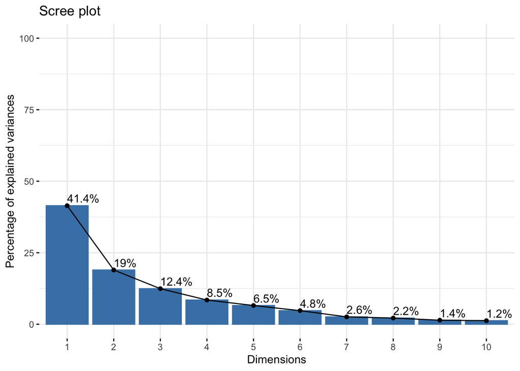

Figura 28: Porcentaje de varianza explicada por cada componente principal a partir de los datos de 2019.

A partir de la cuarta componente, el incremento en la varianza explicada es marginal, por lo que es razonable trabajar con dos o tres componentes. El círculo de correlaciones (Figura 29) permite visualizar las relaciones entre variables y su representación en el plano principal.

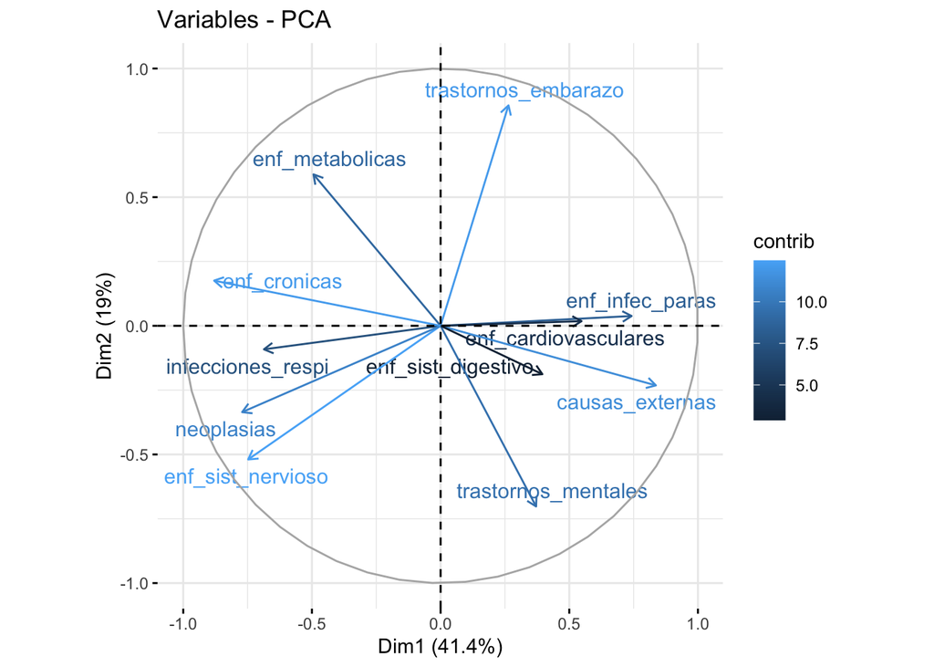

Figura 29: Círculo de correlaciones del ACP calculado a partir de los datos de 2019.

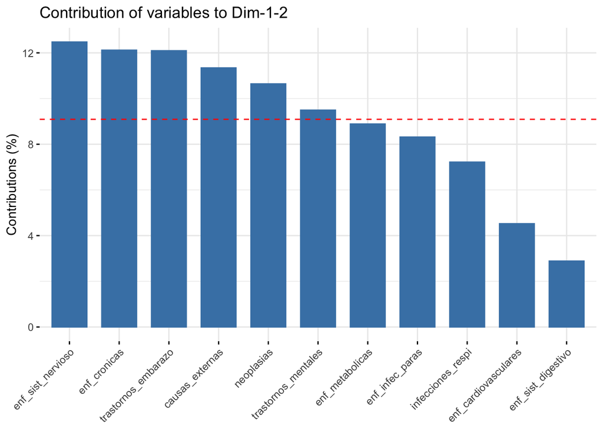

Figura 30: Contribuciones de cada variable al plano principal del ACP.